# data analysis: joint attention (BOSCA)

Nico Bast

2024-07-26

- working title: longitudinal development of reactive joint attention after early intervention in autistic preschoolers

# 1 prepare data sets

- data is loaded from different files and converted to a format that can be analyzed in linear mixed models

## 1.1 load data

- data on local machine
- available on reasonable request

```r
#eye-tracking data: file created by script: data_preprocessing_jointattention
load(paste0(project_path,'/data/all_data_preprocessed_FINAL_jointatt_140324.Rdata'))
## --> includes´
## df_trial --> per-trial - includes main outcome measures
## df_jointatt --> per-sample preprocessed data
rm(demogr)


#load demographic separately
load("C:/Users/nico/PowerFolders/data_AFFIP/demogr_total_0424.Rdata")
### --> includes
## demogra --> demographic & questionnaire data from databases (RCT,FU)
## et_demogr --> ET data quality
```

## 1.2 fix data

- data entry with implausible naming

```r
demogr$ID_Studie<-gsub('-K','_K',demogr$ID_Studie)
```

## 1.3 data overview

### 1.3.1 date of measurement

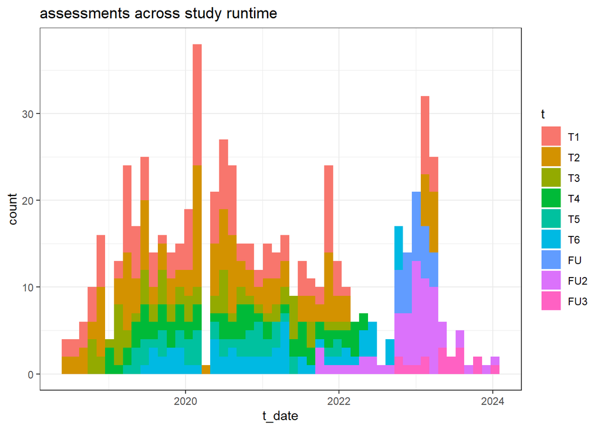

```r
#### - date of measurement #####

ggplot(demogr[!is.na(demogr$t_date),],aes(x=t_date,fill=t))+geom_histogram(bins=50)+theme_bw()+
  labs(title='assessments across study runtime')
```

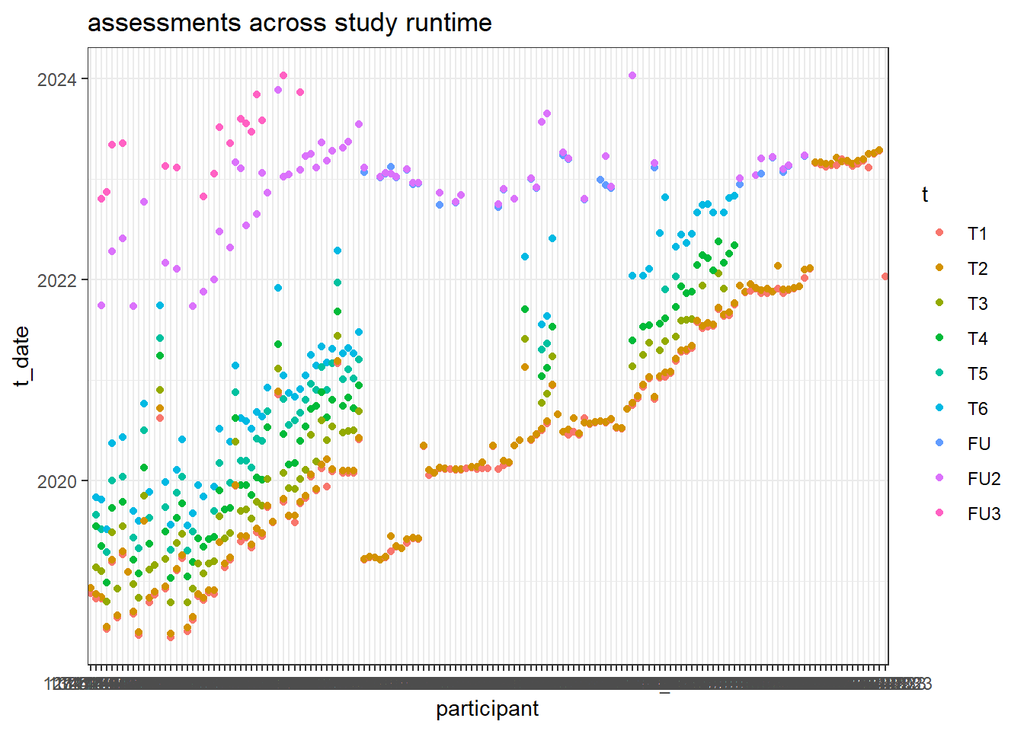

```r
ggplot(demogr[!is.na(demogr$t_date),],aes(x=ID_Bado,y=t_date,color=t))+
  geom_point()+theme_bw()+labs(x='participant')+labs(title='assessments across study runtime')
```

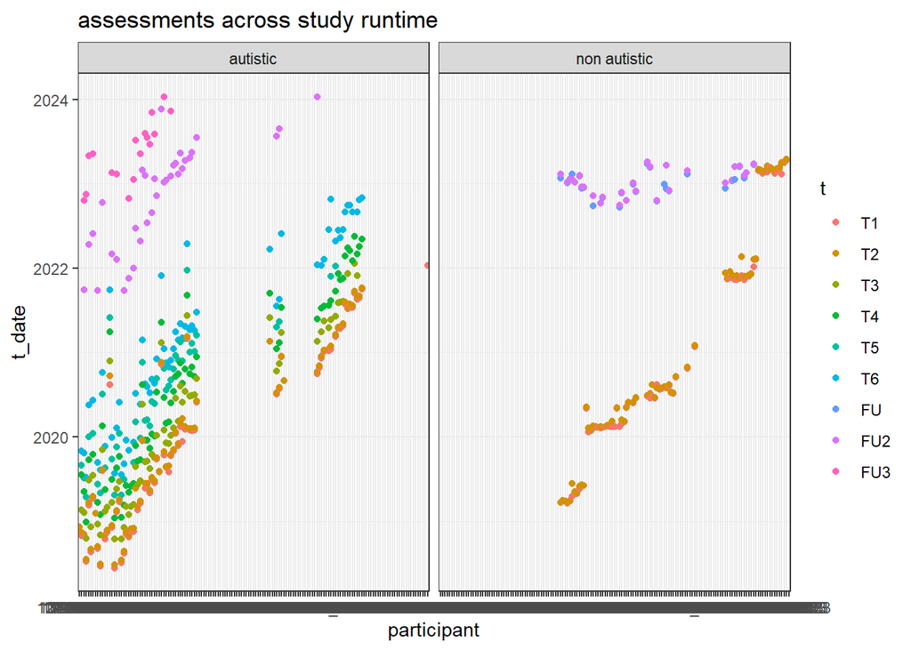

```r
ggplot(demogr[!is.na(demogr$t_date),],aes(x=ID_Bado,y=t_date,color=t))+
  geom_point()+theme_bw()+labs(x='participant')+labs(title='assessments across study runtime')+facet_grid(~group)
```

### 1.3.2 age at assessment

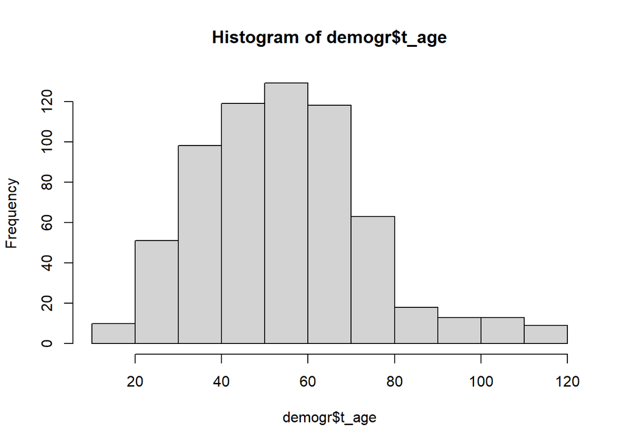

```r
hist(demogr$t_age)
```

## 1.4 extract baseline IQ

- IQ was assessed at T1 and thus is not mathced down below, so retrieve this IQ data and assign it to ID numbers

```r
#allign naming of IDs with demogr
demogr$ID_Studie_merge<-gsub('_K','',demogr$ID_Studie)
demogr$ID_Studie_merge<-gsub('-K','',demogr$ID_Studie_merge)

#table(demogr$ID_Studie_merge)

#extract IQ data
baseline_nonverbal_iq<-demogr$nonverbal_iq[demogr$t=='T1']
baseline_verbal_iq<-demogr$verbal_iq[demogr$t=='T1']
pic<-demogr$ID_Studie_merge[demogr$t=='T1']

df_iq_baseline<-data.frame(pic,baseline_nonverbal_iq,baseline_verbal_iq)
```

## 1.5 rename timepoint variable

-define timepoint variable so that non-autistic and autistic allign in timepoints: - e.g. T2 was baseline in autistic, K was baseline in non-autistic –> all T2

```r
#in per-trial data
df_trial$t<-with(df_trial,dplyr::case_when(timepoint=='T2' ~ 'T2',
                                    timepoint=='T4' ~ 'T4',
                                    timepoint=='T6' ~ 'T6',
                                    timepoint=='K' ~ 'T2',
                                    timepoint=='K_FU' ~ 'FU2',
                                    timepoint=='FU2' ~ 'FU2',
                                    timepoint=='FU3' ~ 'FU3',
                                    ))


#in per-sample data
df_jointatt$t<-with(df_jointatt,dplyr::case_when(timepoint=='T2' ~ 'T2',
                                    timepoint=='T4' ~ 'T4',
                                    timepoint=='T6' ~ 'T6',
                                    timepoint=='K' ~ 'T2',
                                    timepoint=='K_FU' ~ 'FU2',
                                    timepoint=='FU2' ~ 'FU2',
                                    timepoint=='FU3' ~ 'FU3',
                                    ))


df_jointatt$t<-ordered(df_jointatt$t, levels = c("T2", "T4", "T6", 'FU2', 'FU3'))
df_trial$t<-ordered(df_trial$t, levels = c("T2", "T4", "T6", 'FU2', 'FU3'))
```

## 1.6 merge demographic data to trial data

```r
#### --> merge df_timepoint to df_trial ####
df_trial<-merge(df_trial[,names(df_trial)!='group'],demogr,
                by.x=c('pic','t'),
                by.y=c('ID_Studie_merge','t'))
#### --> merge df_baseline_iq to df_trial ####
df_trial<-merge(df_trial,df_iq_baseline,by='pic',all.x=T)
```

## 1.7 rename gender

- from German names to international

```r
#rename variables
df_trial$gender<-ifelse(df_trial$Geschlecht_Index=='weiblich','f','m')
```

## 1.8 define group variable

- 3 groups:
- autistic (early intervention: A-FFIP)
- autistic (early intervention as usual: EAIU),
- non-autistic

```r
df_trial$rndm<-ifelse(df_trial$group=='non autistic','non autistic',df_trial$rndm)
df_trial$rndm<-as.factor(df_trial$rndm)
levels(df_trial$rndm)<-c('autistic A-FFIP','autistic TAU','non autistic')

demogr$rndm<-ifelse(demogr$group=='non autistic','non autistic',demogr$rndm)
demogr$rndm<-as.factor(demogr$rndm)
levels(demogr$rndm)<-c('autistic A-FFIP','autistic TAU','non autistic')
```

## 1.9 merge demographic data to eye-tracking sample data

- data derived from eye-tracker is merged with corresponding database entries

```r
df_sample<-df_trial[!duplicated(interaction(df_trial$t,df_trial$pic)),]
df_sample<-df_sample[,names(df_sample) %in% c('pic','t','rndm','gender','t_age','baseline_nonverbal_iq')]

df_jointatt<-merge(df_jointatt,df_sample,by = c('pic','t'),all.x=T)
```

## 1.10 reduce raw eye-tracking data set

- remove timepoint FU3 as very few cases
- remove data that has no group (rndm is na)

```r
df_jointatt<-df_jointatt[!is.na(df_jointatt$rndm),]
df_jointatt<-df_jointatt[df_jointatt$t!='FU3',]
```

## 1.11 aggregate eye-tracking metrics

- based on per-trial data
- mean or sum value per timepoint

```r
pic<-as.factor(with(df_trial,by(pic,droplevels(interaction(pic,t)),head,n=1)))
levels(pic)<-levels(df_trial$pic)

t<-as.factor(with(df_trial,by(t,droplevels(interaction(pic,t)),head,n=1)))
levels(t)<-levels(df_trial$t)

rndm<-as.factor(with(df_trial,by(rndm,droplevels(interaction(pic,t)),head,n=1)))
levels(rndm)<-levels(df_trial$rndm)

gender<-as.factor(with(df_trial,by(gender,droplevels(interaction(pic,t)),head,n=1)))

df_boolean<-aggregate(df_trial[,names(df_trial) %in% c('target_missed',
                                                       'rja_any',
                                                       'rja_occurances')],
          by=list(df_trial$pic,df_trial$t),
          FUN=sum,na.rm=T)


df_metrics<-aggregate(df_trial[,names(df_trial) %in% c('baseline_pd','rpd_middle',
                                           'time_to_target',"gazeduration_head",
                                           'gazeduration_target','rja_duration','no_data',                                     'saccade_duration','fixation_duration','t_age','nonverbal_iq')],
          by=list(df_trial$pic,df_trial$t),
          FUN=mean,na.rm=T)



df_et_agg<-cbind(pic,t,rndm,gender,df_metrics,df_boolean)
```

## 1.12 completed measurements by participants

```r
df_measurements<-with(df_trial,table(pic,t))
pic<-row.names(df_measurements)
col_names<-colnames(df_measurements)

df_measurements<-data.frame(matrix(ifelse(df_measurements %in% c(8,16),T,F),nrow=143,ncol=5))
colnames(df_measurements)<-col_names
row.names(df_measurements)<-pic

FU_complete<-apply(df_measurements,1,function(x){
  dplyr::case_when(x['T2'] &  x['FU2'] ~ TRUE,
                   !x['T2'] ~ FALSE,
                   !x['FU2'] ~ FALSE)
})

RCT_complete<-apply(df_measurements,1,function(x){
  dplyr::case_when(x['T2'] & x['T4'] & x['T6'] ~ TRUE,
                   !x['T4'] ~ FALSE,
                   !x['T6'] ~ FALSE)
})

df_measurements<-data.frame(pic,df_measurements,FU_complete,RCT_complete)
df_measurements<-df_measurements[,names(df_measurements) %in% c('pic','FU_complete','RCT_complete')]

table(df_measurements$RCT_complete)
```

```
##
## FALSE  TRUE
##   100    37
```

```r
table(df_measurements$FU_complete)
```

```
##
## FALSE  TRUE
##    98    45
```

```r
#merge to existing dataframes
df_trial<-merge(df_trial,df_measurements,by='pic')
df_et_agg<-merge(df_et_agg,df_measurements,by='pic')
```

# 2 matching

- more female participants in non autistic group
- exclude female non autistic participants that have no complete assessments

```r
df_sample<-df_trial[df_trial$t=='T2',]
df_sample<-df_sample[!duplicated(df_sample$pic),]

with(df_sample,table(gender,FU_complete,rndm))
```

```
## , , rndm = autistic A-FFIP
##
##       FU_complete
## gender FALSE TRUE
##      f     3    3
##      m    20    6
##
## , , rndm = autistic TAU
##
##       FU_complete
## gender FALSE TRUE
##      f     2    2
##      m    16    8
##
## , , rndm = non autistic
##
##       FU_complete
## gender FALSE TRUE
##      f    20   16
##      m    26   10
```

```r
exclude_ids<-as.character(with(df_sample,pic[!FU_complete & gender=='f' & rndm=='non autistic']))
exclude_ids<-exclude_ids[!is.na(exclude_ids)]

exclude_ids
```

```
##  [1] "902" "910" "920" "921" "922" "926" "927" "928" "929" "930" "935" "940"
## [13] "941" "949" "952" "955" "960" "961" "969" "977"
```

```r
#exclude data in data sets
df_trial<-df_trial[!(df_trial$pic %in% exclude_ids),]
df_jointatt<-df_jointatt[!(df_jointatt$pic %in% exclude_ids),]
df_et_agg<-df_et_agg[!(df_et_agg$pic %in% exclude_ids),]
demogr<-demogr[!(demogr$ID_Studie_merge %in% exclude_ids),]
```

- exclude ids in non-autistic group with highest non verbal IQ
- currently not evaluated

```r
df_sample<-demogr[demogr$t %in% c('T1','T2'),]
df_sample<-df_sample[!duplicated(df_sample$ID_Studie_merge),]

tail(sort(df_sample$nonverbal_iq[df_sample$rndm=='non autistic']))

exclude_ids<-as.character(df_sample$ID_Studie_merge[df_sample$nonverbal_iq >= 110 & df_sample$rndm=='non autistic' & df_sample$Geschlecht_Index == 'weiblich' & df_sample$t_age < 36])

exclude_ids<-exclude_ids[!is.na(exclude_ids)]
exclude_ids

#exclude data in data sets
df_trial<-df_trial[!(df_trial$pic %in% exclude_ids),]
df_jointatt<-df_jointatt[!(df_jointatt$pic %in% exclude_ids),]
df_et_agg<-df_et_agg[!(df_et_agg$pic %in% exclude_ids),]
demogr<-demogr[!(demogr$ID_Studie_merge %in% exclude_ids),]
```

# 3 clean workspace

```r
rm(df_metrics)
rm(df_boolean)
rm(df_iq_baseline)
rm(df_measurements)
```

# 4 exclude participants with low data quality

- more than 50% missing data per trial
- two participants at follow up in TAU group

```r
interaction(df_et_agg$pic,df_et_agg$t)[df_et_agg$no_data>0.5]
```

```
##  [1] <NA>    <NA>    <NA>    <NA>    <NA>    <NA>    <NA>    <NA>    069.FU2
## [10] <NA>    073.FU2 074.T4  <NA>    <NA>    <NA>    <NA>    097.T4  <NA>
## [19] <NA>    <NA>    <NA>    <NA>
## 715 Levels: 003.T2 005.T2 006.T2 011.T2 012.T2 013.T2 016.T2 017.T2 ... 994.FU3
```

```r
exclude_ids<-c('069_fu2','073_fu2')

df_trial<-df_trial[!df_trial$id %in% exclude_ids,]
df_sample<-df_sample[!df_sample$id %in% exclude_ids,]

exclude_ids<-c('069.FU2','073.FU2')
df_et_agg$id<-interaction(df_et_agg$pic,df_et_agg$t)
demogr$id<-interaction(demogr$ID_Studie,demogr$t)

df_et_agg<-df_et_agg[!df_et_agg$id %in% exclude_ids,]
demogr<-demogr[!demogr$id %in% exclude_ids,]
```

# 5 sample description

- based on df_trial and df_et_agg
- by timepoint and by group

## 5.1 descriptive table - 3 groups

- statistics table of non-autistic, autistic TAU, and autistic A-FFIP (treatment) groups
- T4 timepoint (+6months) not considered for reasons of model parsimony

```r
#one value per timepoint and participant
df_sample<-df_trial[!duplicated(interaction(df_trial$t,df_trial$pic)),]
with(df_sample,table(rndm,t))
```

```
##                  t
## rndm              T2 T4 T6 FU2 FU3
##   autistic A-FFIP 32 31 27  11   5
##   autistic TAU    28 22 20  12   7
##   non autistic    52  0  0  26   0
```

```r
#function for descriptives of metric variables
fun_return_descriptive<-function(variable,group,rounding=2,scaling=1){
  mean_values<-by(variable,group,function(x){round(mean(x,na.rm=T),rounding)})
  sd_values<-by(variable,group,function(x){round(sd(x,na.rm=T),rounding)})
  min_values<-by(variable,group,function(x){round(min(x,na.rm=T),rounding)})
  max_values<-by(variable,group,function(x){round(max(x,na.rm=T),rounding)})
  mean_values<-mean_values*scaling
  sd_values<-sd_values*scaling
  min_values<-min_values*scaling
  max_values<-max_values*scaling
  paste0(mean_values,'/',sd_values,' ','[',min_values,'-',max_values,']')
}

#interested variables on group level:
n_timepoint<-sapply(with(df_sample[df_sample$t %in% c('T2','FU2'),],by(t,rndm,table)),
                    function(x){paste(x[1],'/',x[4])})

gender_sample<-sapply(with(df_sample[df_sample$t=='T2',],by(gender,rndm,table)),
       function(x){paste(x[1],'/',x[2])})

age_baseline<-with(df_sample[df_sample$t=='T2',],fun_return_descriptive(t_age,rndm))
age_followup<-with(df_sample[df_sample$t=='FU2',],fun_return_descriptive(t_age,rndm))

iq_baseline<-with(demogr[demogr$t=='T1',],fun_return_descriptive(nonverbal_iq,rndm))
iq_followup<-with(demogr[demogr$t %in% c('FU','FU2'),],fun_return_descriptive(nonverbal_iq,rndm))

demogr$developmental_age<-with(demogr,nonverbal_iq * t_age / 100)
diq_baseline<-with(demogr[demogr$t=='T1',],fun_return_descriptive(developmental_age,rndm))
diq_followup<-with(demogr[demogr$t %in% c('FU','FU2'),],fun_return_descriptive(developmental_age,rndm))

srs_baseline<-with(demogr[demogr$t %in% c('T1','T2'),],
                   fun_return_descriptive(srs16_sum,rndm))
srs_followup<-with(demogr[demogr$t %in% c('FU2','FU'),],
                   fun_return_descriptive(srs16_sum,rndm))

rbsr_baseline<-with(demogr[demogr$t %in% c('T1','T2'),],
                   fun_return_descriptive(RBSR_ges,rndm))
rbsr_followup<-with(demogr[demogr$t %in% c('FU2','FU'),],
                   fun_return_descriptive(RBSR_ges,rndm))

cbcl_baseline<-with(demogr[demogr$t %in% c('T1','T2'),],
                   fun_return_descriptive(CBCL_T_GES,rndm))
cbcl_followup<-with(demogr[demogr$t %in% c('FU2','FU'),],
                   fun_return_descriptive(CBCL_T_GES,rndm))

asd_severity_baseline<-with(df_sample[df_sample$t %in% c('T2') & df_sample$rndm!='non autistic',],
                   fun_return_descriptive(Severity_Gesamt,rndm))
asd_severity_followup<-with(df_sample[df_sample$t %in% c('FU2') & df_sample$rndm!='non autistic',],
                   fun_return_descriptive(Severity_Gesamt,rndm))

# escs_rja_baseline<-with(demogr[demogr$t %in% c('T2','T1') & demogr$rndm!='non autistic',],
#                    fun_return_descriptive(Total_RJA,rndm))
# escs_ija_baseline<-with(demogr[demogr$t %in% c('T2','T1') & demogr$rndm!='non autistic',],
#                    fun_return_descriptive(Total_IJA,rndm))


###ET variables to one value per timepoint
rja_baseline<-with(df_et_agg[df_et_agg$t %in% c('T2'),],
                   fun_return_descriptive(rja_any/16*100,rndm))
rja_followup<-with(df_et_agg[df_et_agg$t %in% c('FU2'),],
                   fun_return_descriptive(rja_any/16*100,rndm))

rja_s_baseline<-with(df_et_agg[df_et_agg$t %in% c('T2'),],
                   fun_return_descriptive(rja_duration,rndm))
rja_s_followup<-with(df_et_agg[df_et_agg$t %in% c('FU2'),],
                   fun_return_descriptive(rja_duration,rndm))

pd_baseline<-with(df_et_agg[df_et_agg$t %in% c('T2'),],
                   fun_return_descriptive(baseline_pd,rndm))
pd_followup<-with(df_et_agg[df_et_agg$t %in% c('FU2'),],
                   fun_return_descriptive(baseline_pd,rndm))

sepr_baseline<-with(df_et_agg[df_et_agg$t %in% c('T2'),],
                   fun_return_descriptive(rpd_middle,rndm))
sepr_followup<-with(df_et_agg[df_et_agg$t %in% c('FU2'),],
                   fun_return_descriptive(rpd_middle,rndm))

fixation_baseline<-with(df_et_agg[df_et_agg$t %in% c('T2'),],
                   fun_return_descriptive(fixation_duration,rndm))
fixation_followup<-with(df_et_agg[df_et_agg$t %in% c('FU2'),],
                   fun_return_descriptive(fixation_duration,rndm))

dataquality_baseline<-with(df_et_agg[df_et_agg$t %in% c('T2'),],
                   fun_return_descriptive(no_data*100,rndm))
dataquality_followup<-with(df_et_agg[df_et_agg$t %in% c('FU2'),],
                   fun_return_descriptive(no_data*100,rndm))

#create one data frame
descriptives_table<-rbind(
  n_timepoint,
  gender_sample,
  age_baseline,
  age_followup,
  diq_baseline,
  diq_followup,
  iq_baseline,
  iq_followup,
  srs_baseline,
  srs_followup,
  rbsr_baseline,
  rbsr_followup,
  cbcl_baseline,
  cbcl_followup,
  asd_severity_baseline,
  asd_severity_followup,
  #escs_rja_baseline,
  #escs_ija_baseline,
  rja_baseline,
  rja_followup,
  rja_s_baseline,
  rja_s_followup,
  pd_baseline,
  pd_followup,
  sepr_baseline,
  sepr_followup,
  fixation_baseline,
  fixation_followup,
  dataquality_baseline,
  dataquality_followup
)

#change NA values
descriptives_table<-gsub('NA/NA \\[NA-NA\\]','-',x=descriptives_table)

#group comparisons
age_b_p<-with(df_sample[df_sample$t=='T2' & df_sample$rndm!='non autistic',],t.test(t_age~rndm))[['p.value']]
age_f_p<-with(df_sample[df_sample$t=='FU2' & df_sample$rndm!='non autistic',],t.test(t_age~rndm))[['p.value']]
iq_b_p<-with(demogr[demogr$t=='T1' & demogr$rndm!='non autistic',],t.test(nonverbal_iq~rndm))[['p.value']]
iq_f_p<-with(demogr[demogr$t %in% c('FU','FU2') & demogr$rndm!='non autistic',],t.test(nonverbal_iq~rndm))[['p.value']]
srs_b_p<-with(demogr[demogr$t %in% c('T1','T2') & demogr$rndm!='non autistic',],t.test(srs16_sum~rndm))[['p.value']]
srs_b_f<-with(demogr[demogr$t %in% c('FU','FU2') & demogr$rndm!='non autistic',],t.test(srs16_sum~rndm))[['p.value']]
cbcl_b_p<-with(demogr[demogr$t %in% c('T1','T2') & demogr$rndm!='non autistic',],t.test(CBCL_T_GES~rndm))[['p.value']]
cbcl_f_p<-with(demogr[demogr$t %in% c('FU','FU2') & demogr$rndm!='non autistic',],t.test(CBCL_T_GES~rndm))[['p.value']]
ados_b_p<-with(df_sample[df_sample$t=='T2' & df_sample$rndm!='non autistic',],t.test(Severity_Gesamt~rndm))[['p.value']]
ados_b_f<-with(df_sample[df_sample$t=='FU2' & df_sample$rndm!='non autistic',],t.test(Severity_Gesamt~rndm))[['p.value']]

var_names<-c(
  'timepoints (baseline/follow-up)',
  'biological sex (female/male)',
  'age (m)',
  '',
  'developmental age (m)',
  '',
  'nonverbal IQ',
  '',
  'SRS-16 total',
  '',
  'RBSR total',
  '',
  'CBCL total t-score',
  '',
  'ADOS CSS',
  '',
  'RJA likelihood (%)',
  '',
  'RJA duration (s)',
  '',
  'baseline pupil size (mm)',
  '',
  'stimulus-evoked pupillary response (mm)',
  '',
  'total fixation duration (s)',
  '',
  'mean missing data (%)',
  ''
  )

timepoint_labels<-c(
  '',
  '',
  'baseline',
  'follow-up',
  'baseline',
  'follow-up',
  'baseline',
  'follow-up',
  'baseline',
  'follow-up',
  'baseline',
  'follow-up',
  'baseline',
  'follow-up',
  'baseline',
  'follow-up',
  'baseline',
  'follow-up',
  'baseline',
  'follow-up',
  'baseline',
  'follow-up',
  'baseline',
  'follow-up',
  'baseline',
  'follow-up',
  'baseline',
  'follow-up'
)

descriptives_table<-cbind(var_names,timepoint_labels,descriptives_table)

table_sample<-descriptives_table %>%
  kbl(caption = "Table 1. Sample description: autistic and non-autistic  groups at baseline and follow-up.",
      col.names = c('','timepoints','A-FFIP - autistic individuals','EIAU - autistic individuals','non-autistic individuals'),
      row.names = F) %>%
  kable_classic(full_width = F, html_font = "Cambria") %>%
  #adds solid line after every row
  row_spec(seq(0, nrow(descriptives_table), 2)[-1], extra_css = "border-bottom: 1px solid;")%>%
  footnote(general = "Mean / SD [Min - Max]")

table_sample
```

Table 1. Sample description: autistic and non-autistic groups at baseline and follow-up.

timepoints

A-FFIP - autistic individuals

EIAU - autistic individuals

non-autistic individuals

timepoints (baseline/follow-up)

32 / 11

28 / 12

52 / 26

biological sex (female/male)

6 / 26

4 / 24

16 / 36

age (m)

baseline

49.6/11.1 [26.63-65.57]

47.58/9.17 [31.4-66.47]

35.85/14.07 [18.33-73.43]

follow-up

86.12/13.22 [64.67-104.5]

84.11/7.53 [73.23-98.87]

70.97/22.95 [35.37-118.23]

developmental age (m)

baseline

28.77/10.62 [16.11-65.08]

28.27/8.97 [16.52-52.95]

35.99/14.68 [16.05-76.61]

follow-up

48.74/35.27 [23.84-104.5]

56.13/31.59 [24.76-95.26]

57.49/16.02 [30.55-85.92]

nonverbal IQ

baseline

59.53/19.22 [31-101]

60.94/17.12 [37-108]

102.1/12.79 [73-128]

follow-up

53.22/36.91 [26-112]

65.75/34.85 [30-108]

103.07/11.55 [79-121]

SRS-16 total

baseline

27.63/8.15 [8-40]

28.1/6.25 [13-39]

4.6/3.13 [0-12]

follow-up

27.21/9.32 [10-43]

31.55/7.15 [22-44]

4.12/3.46 [0-12]

RBSR total

baseline

32.12/22.21 [2-93]

42.39/25.92 [10-126]

8.88/9.26 [0-37]

follow-up

33.36/13.35 [14-54]

53/24.71 [27-102]

6.12/9.51 [0-42]

CBCL total t-score

baseline

64.68/9.78 [46-93]

66.46/9.36 [52-96]

48.08/8.54 [27-64]

follow-up

63.85/6.61 [54-76]

65.88/13.51 [47-87]

48.75/7.99 [36-68]

ADOS CSS

baseline

6.84/1.61 [4-10]

7.21/1.47 [4-10]

follow-up

6.82/1.72 [5-10]

7.5/1.57 [5-10]

RJA likelihood (%)

baseline

21.68/21.88 [0-81.25]

13.17/16.95 [0-68.75]

42.19/31.99 [0-100]

follow-up

34.66/26.86 [0-75]

17.19/20.32 [0-62.5]

52.84/25.05 [0-93.75]

RJA duration (s)

baseline

0.34/0.19 [0.05-0.7]

0.34/0.19 [0.1-0.93]

0.43/0.19 [0-0.92]

follow-up

0.41/0.16 [0.24-0.65]

0.4/0.18 [0.17-0.7]

0.43/0.14 [0.15-0.65]

baseline pupil size (mm)

baseline

4.23/0.51 [2.58-5.27]

4.42/0.49 [3.42-5.68]

4.24/0.48 [3.45-5.85]

follow-up

4.05/0.71 [2.36-5.26]

4.41/0.36 [3.86-4.88]

4.21/0.54 [3.53-5.94]

stimulus-evoked pupillary response (mm)

baseline

0.06/0.17 [-0.37-0.43]

0.06/0.27 [-0.64-0.6]

0.15/0.22 [-0.4-0.78]

follow-up

0.07/0.24 [-0.43-0.36]

0.24/0.31 [-0.14-1.07]

0.14/0.16 [-0.26-0.44]

total fixation duration (s)

baseline

8.19/1.11 [4.64-9.86]

7.96/1.2 [5.42-10.23]

8.97/1.06 [6.41-10.74]

follow-up

8.27/1.64 [3.84-9.6]

8.1/1.15 [5.63-9.29]

9.26/0.87 [6.56-10.56]

mean missing data (%)

baseline

23.07/10.36 [2.03-38.79]

26.64/10.98 [6.64-47.57]

21.89/12.98 [1.02-48.45]

follow-up

25.86/8.95 [13.87-42.67]

28.09/7.87 [16.55-43.41]

16.7/7.99 [3.2-29.65]

Note:

Mean / SD [Min - Max]

```r
save_kable(table_sample, file=paste0(project_path,'/output/tables/table1_sampledescription.html'))
```

## 5.2 descriptive table - autism groups

```r
#one value per timepoint and participant
df_sample<-df_trial[!duplicated(interaction(df_trial$t,df_trial$pic)) &
                      df_trial$rndm!='non autistic' &
                      df_trial$t %in% c('T2','T4','T6','FU2'),]

#remove non.autistic from variable levels
df_sample$rndm<-droplevels(df_sample$rndm)
df_sample$t<-droplevels(df_sample$t)

with(df_sample,table(rndm,t))
```

```
##                  t
## rndm              T2 T4 T6 FU2
##   autistic A-FFIP 32 31 27  11
##   autistic TAU    28 22 20  12
```

```r
#function for descriptives of metric variables
fun_return_descriptive<-function(variable,group,rounding=2,scaling=1){
  mean_values<-by(variable,group,function(x){round(mean(x,na.rm=T),rounding)})
  sd_values<-by(variable,group,function(x){round(sd(x,na.rm=T),rounding)})
  min_values<-by(variable,group,function(x){round(min(x,na.rm=T),rounding)})
  max_values<-by(variable,group,function(x){round(max(x,na.rm=T),rounding)})
  mean_values<-mean_values*scaling
  sd_values<-sd_values*scaling
  min_values<-min_values*scaling
  max_values<-max_values*scaling
  paste0(mean_values,'/',sd_values,' ','[',min_values,'-',max_values,']')
}

#interested variables on group level:
n_timepoint<-sapply(with(df_sample,by(t,rndm,table)),
                    function(x){paste(x[1],'/',x[3],'/',x[4])})

gender_sample<-sapply(with(df_sample[df_sample$t=='T2',],by(gender,rndm,table)),
       function(x){paste(x[1],'/',x[2])})

age_T2<-with(df_sample[df_sample$t=='T2',],fun_return_descriptive(t_age,rndm))
age_T4<-with(df_sample[df_sample$t=='T4',],fun_return_descriptive(t_age,rndm))
age_T6<-with(df_sample[df_sample$t=='T6',],fun_return_descriptive(t_age,rndm))
age_FU<-with(df_sample[df_sample$t=='FU2',],fun_return_descriptive(t_age,rndm))


iq_T2<-with(demogr[demogr$t=='T1' & demogr$rndm!='non autistic',],fun_return_descriptive(nonverbal_iq,rndm))[1:2]
iq_T4<-with(demogr[demogr$t=='T4' & demogr$rndm!='non autistic',],fun_return_descriptive(nonverbal_iq,rndm))[1:2]
iq_T6<-with(demogr[demogr$t=='T6' & demogr$rndm!='non autistic',],fun_return_descriptive(nonverbal_iq,rndm))[1:2]
iq_FU<-with(demogr[demogr$t=='FU2' & demogr$rndm!='non autistic',],fun_return_descriptive(nonverbal_iq,rndm))[1:2]

srs_T2<-with(df_sample[df_sample$t=='T2',],fun_return_descriptive(srs16_sum,rndm))
srs_T4<-with(df_sample[df_sample$t=='T4',],fun_return_descriptive(srs16_sum,rndm))
srs_T6<-with(df_sample[df_sample$t=='T6',],fun_return_descriptive(srs16_sum,rndm))
srs_FU<-with(df_sample[df_sample$t=='FU2',],fun_return_descriptive(srs16_sum,rndm))

rbsr_T2<-with(df_sample[df_sample$t=='T2',],fun_return_descriptive(RBSR_ges,rndm))
rbsr_T4<-with(df_sample[df_sample$t=='T4',],fun_return_descriptive(RBSR_ges,rndm))
rbsr_T6<-with(df_sample[df_sample$t=='T6',],fun_return_descriptive(RBSR_ges,rndm))
rbsr_FU<-with(df_sample[df_sample$t=='FU2',],fun_return_descriptive(RBSR_ges,rndm))

# boscc_T2<-with(df_sample[df_sample$t=='T2',],fun_return_descriptive(BOSCC_Average_Total,rndm))
# boscc_T4<-with(df_sample[df_sample$t=='T4',],fun_return_descriptive(BOSCC_Average_Total,rndm))
# boscc_T6<-with(df_sample[df_sample$t=='T6',],fun_return_descriptive(BOSCC_Average_Total,rndm))
# boscc_T6<-with(df_sample[df_sample$t=='FU2',],fun_return_descriptive(BOSCC_Average_Total,rndm))


cbcl_T2<-with(df_sample[df_sample$t=='T2',],fun_return_descriptive(CBCL_T_GES,rndm))
cbcl_T4<-with(df_sample[df_sample$t=='T4',],fun_return_descriptive(CBCL_T_GES,rndm))
cbcl_T6<-with(df_sample[df_sample$t=='T6',],fun_return_descriptive(CBCL_T_GES,rndm))
cbcl_FU<-with(df_sample[df_sample$t=='FU2',],fun_return_descriptive(CBCL_T_GES,rndm))

##ESCS RJA
escs_rja_T2<-with(df_sample[df_sample$t=='T2',],fun_return_descriptive(Total_RJA,rndm))
escs_rja_T6<-c('-','-')
escs_rja_FU<-c('-','-')

###ET variables to one value per timepoint
rja_T2<-with(df_et_agg[df_et_agg$t %in% c('T2') & df_et_agg$rndm!='non autistic',],
                   fun_return_descriptive(rja_any/16*100,rndm))[1:2]
rja_T4<-with(df_et_agg[df_et_agg$t %in% c('T4') & df_et_agg$rndm!='non autistic',],
                   fun_return_descriptive(rja_any/16*100,rndm))[1:2]
rja_T6<-with(df_et_agg[df_et_agg$t %in% c('T6') & df_et_agg$rndm!='non autistic',],
                   fun_return_descriptive(rja_any/16*100,rndm))[1:2]
rja_FU<-with(df_et_agg[df_et_agg$t %in% c('FU2') & df_et_agg$rndm!='non autistic',],
                   fun_return_descriptive(rja_any/16*100,rndm))[1:2]

rja_s_T2<-with(df_et_agg[df_et_agg$t %in% c('T2') & df_et_agg$rndm!='non autistic',],
                   fun_return_descriptive(rja_duration,rndm))[1:2]
rja_s_T4<-with(df_et_agg[df_et_agg$t %in% c('T4') & df_et_agg$rndm!='non autistic',],
                   fun_return_descriptive(rja_duration,rndm))[1:2]
rja_s_T6<-with(df_et_agg[df_et_agg$t %in% c('T6') & df_et_agg$rndm!='non autistic',],
                   fun_return_descriptive(rja_duration,rndm))[1:2]
rja_s_FU<-with(df_et_agg[df_et_agg$t %in% c('FU2') & df_et_agg$rndm!='non autistic',],
                   fun_return_descriptive(rja_duration,rndm))[1:2]



pd_T2<-with(df_et_agg[df_et_agg$t %in% c('T2') & df_et_agg$rndm!='non autistic',],
                   fun_return_descriptive(baseline_pd,rndm))[1:2]
pd_T4<-with(df_et_agg[df_et_agg$t %in% c('T4') & df_et_agg$rndm!='non autistic',],
                   fun_return_descriptive(baseline_pd,rndm))[1:2]
pd_T6<-with(df_et_agg[df_et_agg$t %in% c('T6') & df_et_agg$rndm!='non autistic',],
                   fun_return_descriptive(baseline_pd,rndm))[1:2]
pd_FU<-with(df_et_agg[df_et_agg$t %in% c('FU2') & df_et_agg$rndm!='non autistic',],
                   fun_return_descriptive(baseline_pd,rndm))[1:2]

sepr_T2<-with(df_et_agg[df_et_agg$t %in% c('T2') & df_et_agg$rndm!='non autistic',],
                   fun_return_descriptive(rpd_middle,rndm))[1:2]
sepr_T4<-with(df_et_agg[df_et_agg$t %in% c('T4') & df_et_agg$rndm!='non autistic',],
                   fun_return_descriptive(rpd_middle,rndm))[1:2]
sepr_T6<-with(df_et_agg[df_et_agg$t %in% c('T6') & df_et_agg$rndm!='non autistic',],
                   fun_return_descriptive(rpd_middle,rndm))[1:2]
sepr_FU<-with(df_et_agg[df_et_agg$t %in% c('FU2') & df_et_agg$rndm!='non autistic',],
                   fun_return_descriptive(rpd_middle,rndm))[1:2]

fixation_T2<-with(df_et_agg[df_et_agg$t %in% c('T2') & df_et_agg$rndm!='non autistic',],
                   fun_return_descriptive(fixation_duration,rndm))[1:2]
fixation_T4<-with(df_et_agg[df_et_agg$t %in% c('T4') & df_et_agg$rndm!='non autistic',],
                   fun_return_descriptive(fixation_duration,rndm))[1:2]
fixation_T6<-with(df_et_agg[df_et_agg$t %in% c('T6') & df_et_agg$rndm!='non autistic',],
                   fun_return_descriptive(fixation_duration,rndm))[1:2]
fixation_FU<-with(df_et_agg[df_et_agg$t %in% c('FU2') & df_et_agg$rndm!='non autistic',],
                   fun_return_descriptive(fixation_duration,rndm))[1:2]



dataquality_T2<-with(df_et_agg[df_et_agg$t %in% c('T2') & df_et_agg$rndm!='non autistic',],
                   fun_return_descriptive(no_data*100,rndm))[1:2]
dataquality_T4<-with(df_et_agg[df_et_agg$t %in% c('T4') & df_et_agg$rndm!='non autistic',],
                   fun_return_descriptive(no_data*100,rndm))[1:2]
dataquality_T6<-with(df_et_agg[df_et_agg$t %in% c('T6') & df_et_agg$rndm!='non autistic',],
                   fun_return_descriptive(no_data*100,rndm))[1:2]

dataquality_FU<-with(df_et_agg[df_et_agg$t %in% c('FU2') & df_et_agg$rndm!='non autistic',],
                   fun_return_descriptive(no_data*100,rndm))[1:2]


#create one data frame
descriptives_table<-rbind(
  n_timepoint,
  gender_sample,
  age_T2,
  #age_T4,
  age_T6,
  age_FU,
  iq_T2,
  #iq_T4,
  iq_T6,
  iq_FU,
  srs_T2,
  #srs_T4,
  srs_T6,
  srs_FU,
  rbsr_T2,
  #rbsr_T4,
  rbsr_T6,
  rbsr_FU,
  # boscc_T2,
  # boscc_T4,
  # boscc_T6,
  cbcl_T2,
  #cbcl_T4,
  cbcl_T6,
  cbcl_FU,
  escs_rja_T2,
  escs_rja_T6,
  escs_rja_FU,
  rja_T2,
  #rja_T4,
  rja_T6,
  rja_FU,
  rja_s_T2,
  #rja_s_T4,
  rja_s_T6,
  rja_s_FU,
  pd_T2,
  #pd_T4,
  pd_T6,
  pd_FU,
  sepr_T2,
  #sepr_T4,
  sepr_T6,
  sepr_FU,
  fixation_T2,
  #fixation_T4,
  fixation_T6,
  fixation_FU,
  dataquality_T2,
  #dataquality_T4,
  dataquality_T6,
  dataquality_FU
)

var_names<-c(
  'timepoints (BL/+12M/+36M)',
  'biological sex (female/male)',
  'age (m)',
  #'',
  '',
  '',
  'nonverbal IQ',
  #'',
  '',
  '',
  'SRS-16 total',
  #'',
  '',
  '',
  'RBSR total',
  #'',
  '',
  '',
  # 'BOSCC total',
  # '',
  # '',
  'CBCL total t-score',
  #'',
  '',
  '',
  'ESCS RJA (%)',
  '',
  '',
  'RJA likelihood (%)',
  #'',
  '',
  '',
  'RJA duration (s)',
  #'',
  '',
  '',
  'baseline pupil size (mm)',
  #'',
  '',
  '',
  'stimulus-evoked pupillary response (mm)',
  #'',
  '',
  '',
  'total fixation duration (s)',
  #'',
  '',
  '',
  'mean missing data (0-1)',
  #'',
  '',
  ''
  )

timepoint_labels<-c(
  '',
  '',
  'baseline',
  #'+6 months',
  '+12 months',
  '+36 months',
  'baseline',
  #'+6 months',
  '+12 months',
  '+36 months',
  'baseline',
  #'+6 months',
  '+12 months',
  '+36 months',
  'baseline',
  #'+6 months',
  '+12 months',
  '+36 months',
  'baseline',
  #'+6 months',
  '+12 months',
  '+36 months',
  'baseline',
  #'+6 months',
  '+12 months',
  '+36 months',
  'baseline',
  #'+6 months',
  '+12 months',
  '+36 months',
  # 'baseline',
  # '+6 months',
  # '+12 months',
  'baseline',
  #'+6 months',
  '+12 months',
  '+36 months',
  'baseline',
  #'+6 months',
  '+12 months',
  '+36 months',
  'baseline',
  #'+6 months',
  '+12 months',
  '+36 months',
  'baseline',
  #'+6 months',
  '+12 months',
  '+36 months',
  'baseline',
  #'+6 months',
  '+12 months',
  '+36 months'
)

descriptives_table<-cbind(var_names,timepoint_labels,descriptives_table)

table_sample<-descriptives_table %>%
  kbl(caption = "Table 2. Sample description: autistic groups at baseline (BL), end-of-treatment (+12M), and follow-up (+36M).",
      col.names = c('','timepoints','A-FFIP - autistic individuals','EAIU - autistic individuals'),
      row.names = F) %>%
  kable_classic(full_width = F, html_font = "Cambria") %>%
  #adds solid line after every row
  row_spec(c(2,seq(2, nrow(descriptives_table), 3)[-c(1)]), extra_css = "border-bottom: 1px solid;") %>%
  footnote(general = "Mean / SD [Min - Max]")

table_sample
```

Table 2. Sample description: autistic groups at baseline (BL), end-of-treatment (+12M), and follow-up (+36M).

timepoints

A-FFIP - autistic individuals

EAIU - autistic individuals

timepoints (BL/+12M/+36M)

32 / 27 / 11

28 / 20 / 12

biological sex (female/male)

6 / 26

4 / 24

age (m)

baseline

49.6/11.1 [26.63-65.57]

47.58/9.17 [31.4-66.47]

+12 months

64.98/11.39 [47.6-80.43]

60.6/10.1 [44.9-79.03]

+36 months

86.12/13.22 [64.67-104.5]

84.11/7.53 [73.23-98.87]

nonverbal IQ

baseline

59.53/19.22 [31-101]

60.94/17.12 [37-108]

+12 months

56.24/23.6 [28-110]

59.24/20.84 [34-114]

+36 months

53.22/36.91 [26-112]

65.75/34.85 [30-108]

SRS-16 total

baseline

27.06/8.3 [8-40]

28.57/6.17 [15-39]

+12 months

24.19/8.84 [4-39]

27.54/6.27 [13-36]

+36 months

26.9/10.35 [10-43]

33.11/6.86 [25-44]

RBSR total

baseline

28/17.77 [2-67]

47.05/27.95 [10-126]

+12 months

29.38/23.13 [3-92]

42.54/27.84 [8-87]

+36 months

35.9/13.5 [14-54]

57.11/25.66 [27-102]

CBCL total t-score

baseline

63.47/7.99 [46-82]

66.96/10.19 [52-96]

+12 months

63.38/14.38 [40-93]

65.77/8.8 [53-82]

+36 months

66/5.87 [58-76]

67.5/14.94 [47-87]

ESCS RJA (%)

baseline

51.1/28.09 [7.14-100]

44.37/27.83 [0-100]

+12 months

+36 months

RJA likelihood (%)

baseline

21.68/21.88 [0-81.25]

13.17/16.95 [0-68.75]

+12 months

26.62/18.8 [0-68.75]

19.38/22.75 [0-81.25]

+36 months

34.66/26.86 [0-75]

17.19/20.32 [0-62.5]

RJA duration (s)

baseline

0.34/0.19 [0.05-0.7]

0.34/0.19 [0.1-0.93]

+12 months

0.3/0.11 [0.07-0.46]

0.28/0.14 [0.15-0.61]

+36 months

0.41/0.16 [0.24-0.65]

0.4/0.18 [0.17-0.7]

baseline pupil size (mm)

baseline

4.23/0.51 [2.58-5.27]

4.42/0.49 [3.42-5.68]

+12 months

4.29/0.55 [2.51-5.19]

4.28/0.49 [3.26-5.2]

+36 months

4.05/0.71 [2.36-5.26]

4.41/0.36 [3.86-4.88]

stimulus-evoked pupillary response (mm)

baseline

0.06/0.17 [-0.37-0.43]

0.06/0.27 [-0.64-0.6]

+12 months

0.06/0.2 [-0.28-0.46]

0.06/0.2 [-0.23-0.53]

+36 months

0.07/0.24 [-0.43-0.36]

0.24/0.31 [-0.14-1.07]

total fixation duration (s)

baseline

8.19/1.11 [4.64-9.86]

7.96/1.2 [5.42-10.23]

+12 months

7.97/0.97 [5.72-10.03]

7.56/1.82 [3.79-10.31]

+36 months

8.27/1.64 [3.84-9.6]

8.1/1.15 [5.63-9.29]

baseline

23.07/10.36 [2.03-38.79]

26.64/10.98 [6.64-47.57]

+12 months

26.27/8.52 [10.9-41.48]

26.86/12.14 [1.85-47.3]

+36 months

25.86/8.95 [13.87-42.67]

28.09/7.87 [16.55-43.41]

Note:

Mean / SD [Min - Max]

```r
save_kable(table_sample, file=paste0(project_path,'/output/tables/table2_sampledescription_autismgroups.html'))
```

## 5.3 autism symptom severity

-comparison of autism symptom severity

```r
#one value per timepoint and participant
df_sample<-df_trial[!duplicated(interaction(df_trial$t,df_trial$pic)) &
                      df_trial$t %in% c('T1','T2'),]

#custom color
custom_color<-c('autistic A-FFIP' = brewer.pal(3,'Dark2')[1],
                "autistic TAU" = brewer.pal(3,'Dark2')[2],
                "non autistic" = brewer.pal(3,'Dark2')[3]
                )

table(df_sample$rndm)
```

```
##
## autistic A-FFIP    autistic TAU    non autistic
##              32              28              52
```

```r
with(df_sample,psych::describe(Severity_Gesamt))
```

```
##    vars  n mean   sd median trimmed  mad min max range skew kurtosis  se
## X1    1 60 7.02 1.55      7    7.02 1.48   4  10     6 0.08    -0.77 0.2
```

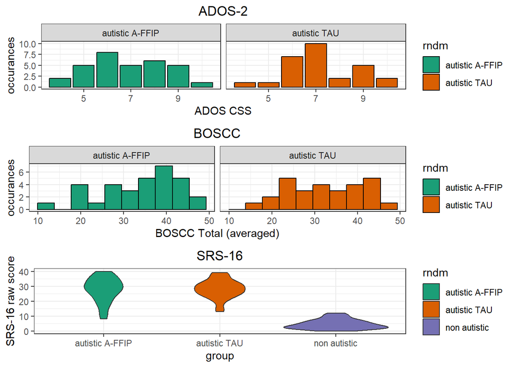

```r
#distribution ADOS
g1<-ggplot(df_sample[df_sample$group=='autistic' & !is.na(df_sample$Severity_Gesamt),],
           aes(x=Severity_Gesamt,fill=rndm)) +
  geom_bar(color=1) +
  labs(x="ADOS CSS", y="occurances",title="ADOS-2") +
  theme(plot.title = element_text(hjust = 0.5))+
  scale_fill_manual(values = custom_color[1:2])+
  facet_wrap(~rndm)
#distribution BOSCC
g2<-ggplot(df_sample[df_sample$group=='autistic' & !is.na(df_sample$BOSCC_Average_Total),],
           aes(x=BOSCC_Average_Total,fill=rndm)) +
  geom_histogram(bins=10,color=1) +
  labs(x="BOSCC Total (averaged)", y="occurances",title="BOSCC") +
  theme(plot.title = element_text(hjust = 0.5))+
  scale_fill_manual(values = custom_color[1:2])+
  facet_wrap(~rndm)
#distribution SRS
g3<-ggplot(demogr[!is.na(demogr$srs16_sum) & demogr$t %in% c('T1','T2') & !is.na(demogr$rndm),],
       aes(x=rndm, y=srs16_sum, fill=rndm)) +
  geom_violin()+
  labs(x="group", y="SRS-16 raw score",title="SRS-16") +
  scale_fill_manual(values=custom_color)+
  theme(plot.title = element_text(hjust = 0.5))

grid.arrange(g1,g2,g3)
```

## 5.4 date of assessment variation

- provide variation of date of assessment for section “procedure” in manuscript
- in months: first = end-of-treatment - baseline, second: follow-up - baseline

```r
demogr_ass<-demogr[demogr$t %in% c('T2','T6','FU2') & demogr$ID_Studie %in% unique(df_trial$pic),]
demogr_ass<-demogr_ass[,names(demogr_ass) %in% c('ID_Studie','t','t_date')]
demogr_ass$t<-droplevels(as.factor(demogr_ass$t))

demogr_ass<-reshape2::dcast(demogr_ass,ID_Studie~t,
                          value.var = 't_date')


timespan_T6_T2<-with(demogr_ass,T6-T2)/30
sd(timespan_T6_T2,na.rm=T)
```

```
## [1] 1.512632
```

```r
timespan_FU2_T2<-with(demogr_ass,FU2-T2)/30
sd(timespan_FU2_T2,na.rm=T)
```

```
## [1] 2.023251
```

# 6 data inspection

## 6.1 eye-tracking calibration quality

```r
t(table(et_demogr$calib_quality)) %>%
  kbl(caption = "eye tracking data quality") %>%
  kable_paper("hover", full_width = T)
```

eye tracking data quality

| good | medium | bad | failed | else |
| --- | --- | --- | --- | --- |
| 142 | 50 | 32 | 84 | 13 |

## 6.2 available data sets

derived from entries in demographic data files

```r
#database entries that have ET data
t(table(demogr$ID_Studie %in% et_demogr$ID,demogr$t)) %>%
  kbl(caption = "data base entries with eye-tracking") %>%
  kable_paper("hover", full_width = T)
```

data base entries with eye-tracking

|  | FALSE | TRUE |
| --- | --- | --- |
| T1 | 9 | 124 |
| T2 | 9 | 124 |
| T3 | 9 | 124 |
| T4 | 9 | 124 |
| T5 | 9 | 124 |
| T6 | 9 | 124 |
| FU | 9 | 124 |
| FU2 | 9 | 122 |
| FU3 | 9 | 124 |

```r
 print('Eye-tracking is missing foir these that have database entries:')
```

```
## [1] "Eye-tracking is missing foir these that have database entries:"
```

```r
 unique(demogr$ID_Studie[!(demogr$ID_Studie %in% et_demogr$ID)])
```

```
## [1] "015"   "039"   "063"   "068"   "077"   "089"   "109"   "925_K" "972_K"
```

```r
#ET data that have database entries
t(table(et_demogr$ID %in% demogr$ID_Studie,et_demogr$t)) %>%
  kbl(caption = "eye-tracking with data base entries") %>%
  kable_paper("hover", full_width = T)
```

eye-tracking with data base entries

|  | FALSE | TRUE |
| --- | --- | --- |
| T2 | 18 | 118 |
| T4 | 0 | 57 |
| T6 | 0 | 52 |
| FU2 | 3 | 55 |
| FU3 | 0 | 15 |
| FU4 | 0 | 3 |

derived from per-sample eye-tracking data

```r
#individual data sets
length(unique(df_jointatt$id)) #data of 265 measurement timepoints after matching (April 2024)
```

```
## [1] 265
```

```r
length(unique(df_jointatt$pic)) #data of 120 participants after matching (April 2024)
```

```
## [1] 120
```

```r
    # #available eye tracking data
    # by(df_jointatt$id,df_jointatt$timepoint,function(x){length(unique(x))})
    # ##--> after matching (September 2022): K = 44, T2 = 51, T4 = 44, T6 = 32
    # ##--> without matching (March 2023): K = 65, T2 = 62, T4 = 53, T6 = 47, K_FU = 20, FU2 = 15, FU3 = 2
    # ##--> without matching (March 2024): K = 75, T2 = 62, T4 = 53, T6 = 47, K_FU = 26, FU2 = 25, FU3 = 12
```

## 6.3 data distribution

based on preprocessed eye-tracking data

```r
#missing data in preprocessed pupil dilation data
table(is.na(df_jointatt$rpd))[2]/sum(table(is.na(df_jointatt$rpd))) #--> 43.2 missing data in pupil data
```

```
##      TRUE
## 0.4373347
```

```r
table(is.na(df_jointatt$gazepos_x))[2]/sum(table(is.na(df_jointatt$gazepos_x))) #--> 51.8% missing in gaze x
```

```
##      TRUE
## 0.5221892
```

```r
table(is.na(df_jointatt$gazepos_y))[2]/sum(table(is.na(df_jointatt$gazepos_y))) #--> 56.0% missing  in gaze y
```

```
##      TRUE
## 0.5658392
```

```r
#gaze behavior
table(df_jointatt$saccade) #roughly 10% saccade data is plausible
```

```
##
##   FALSE    TRUE
## 4410166  312293
```

```r
table(df_jointatt$fixation) #roughly 90% fixation data is plausible
```

```
##
##   FALSE    TRUE
##  377933 5797763
```

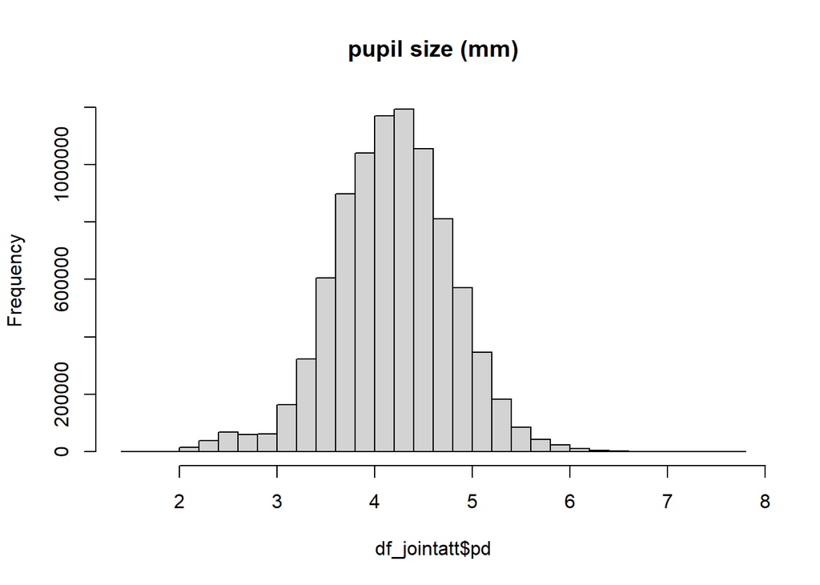

```r
#data distribution --> exclude implausible
hist(df_jointatt$pd,30,main='pupil size (mm)')
```

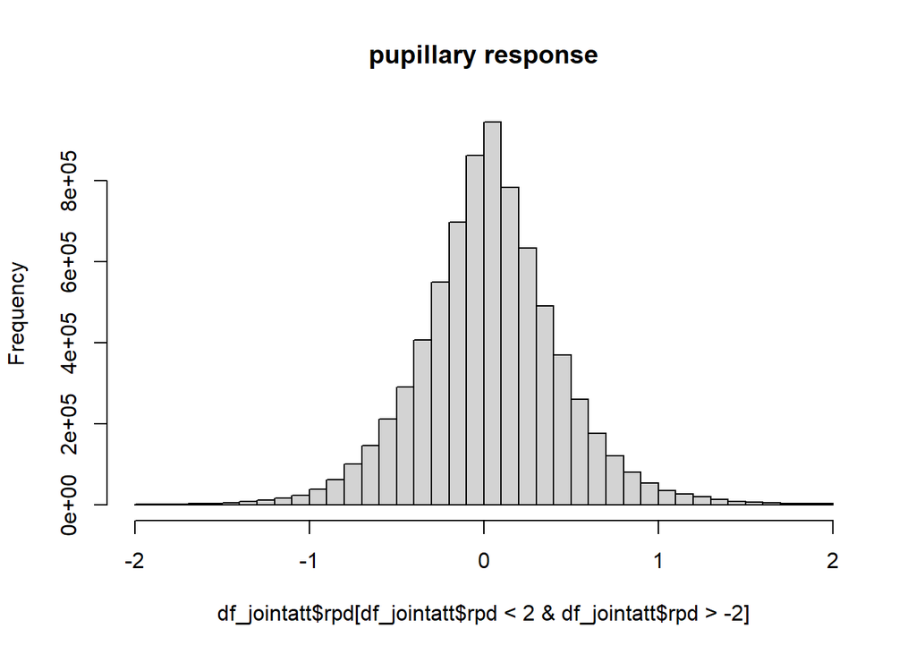

```r
#hist(df_jointatt$baseline_pd,30,main='baseline pupil size (mm)') #pupil size in first 500ms of a trial
hist(df_jointatt$rpd[df_jointatt$rpd<2 & df_jointatt$rpd>-2],30,main='pupillary response') #--> implausible outlier #pupil response (baseline pd - pupil size)
```

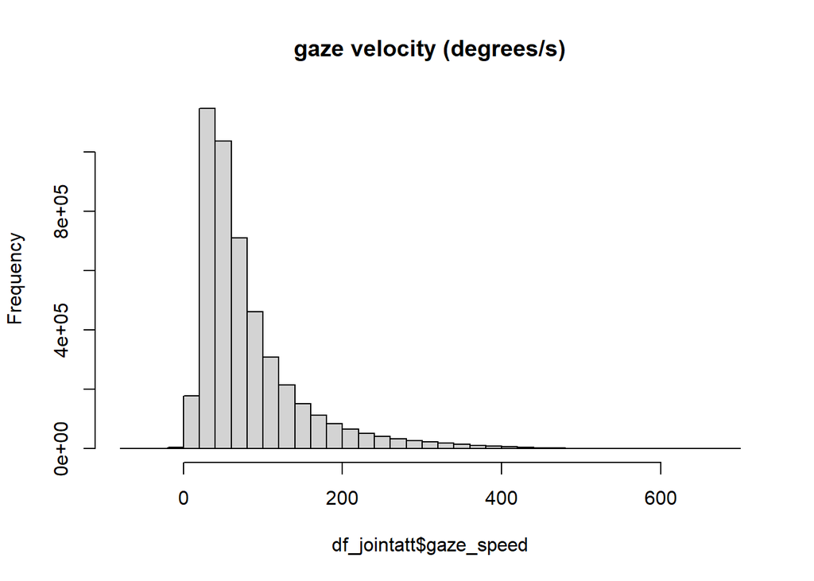

```r
hist(df_jointatt$gaze_speed,30,main='gaze velocity (degrees/s)')
```

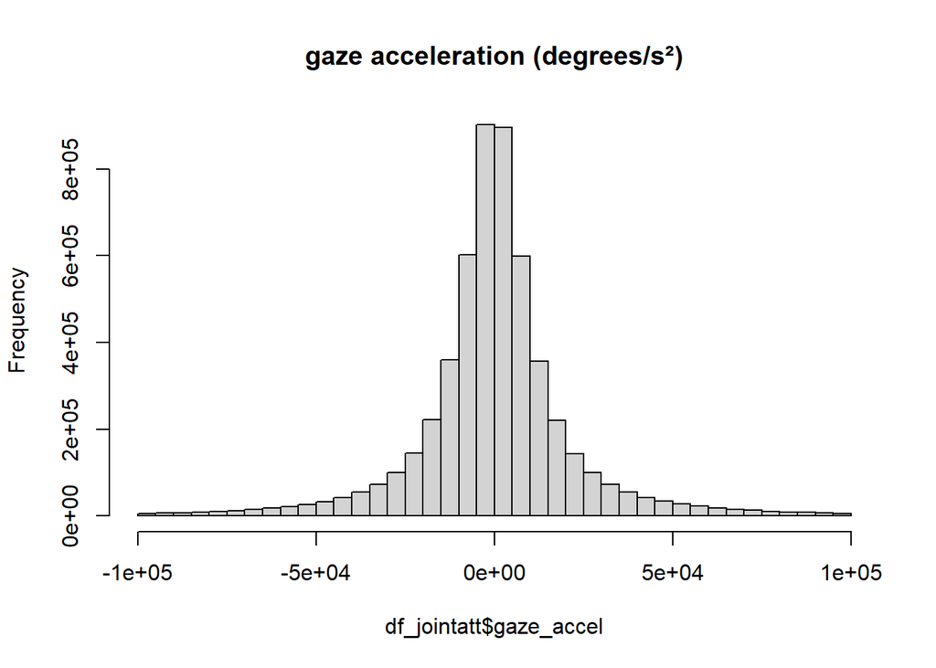

```r
hist(df_jointatt$gaze_accel,30,main='gaze acceleration (degrees/s²)')
```

[figure not shown]

```r
hist(df_jointatt$gazepos_y,30,main='gaze location on x-axis (0-1)')
```

[figure not shown]

```r
hist(df_jointatt$gazepos_x,30,main='gaze location on y-axis (0-1)')
```

```r
# #VALID TRIALS by participants
# hist(as.numeric(with(df_jointatt[df_jointatt$fixation,],
#                      by(index_trial,id,function(x){length(unique(x))}))),xlab='trials',main='trials with fixation data by participant')
```

# 7 data visualization

utilizes per-sample eye-tracking data

## 7.1 gaze behavior

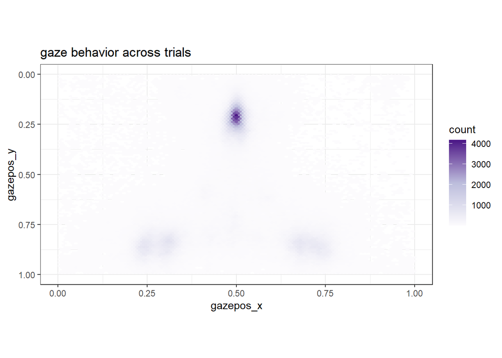

```r
### --> visualize gaze behavior (for INSAR 2023 abstract) ####

##define percentage of data sampling for visualization
subsample<-sample(1:nrow(df_jointatt),nrow(df_jointatt)/sampling_factor)
#--> select 10% of data for faster plotting (faster rendering)

custom_palette<-brewer.pal(8,'Purples')[c(1,4,8)]

##gaze locations across video
ggplot(df_jointatt[subsample,],aes(x=gazepos_x,y=gazepos_y))+
  geom_hex(bins=100)+
  scale_fill_gradientn(colours=custom_palette)+
  ylim(1,0)+xlim(0,1)+coord_fixed(ratio = 9/16)+
  #scale_fill_viridis_c()+
  labs(title='gaze behavior across trials')
```

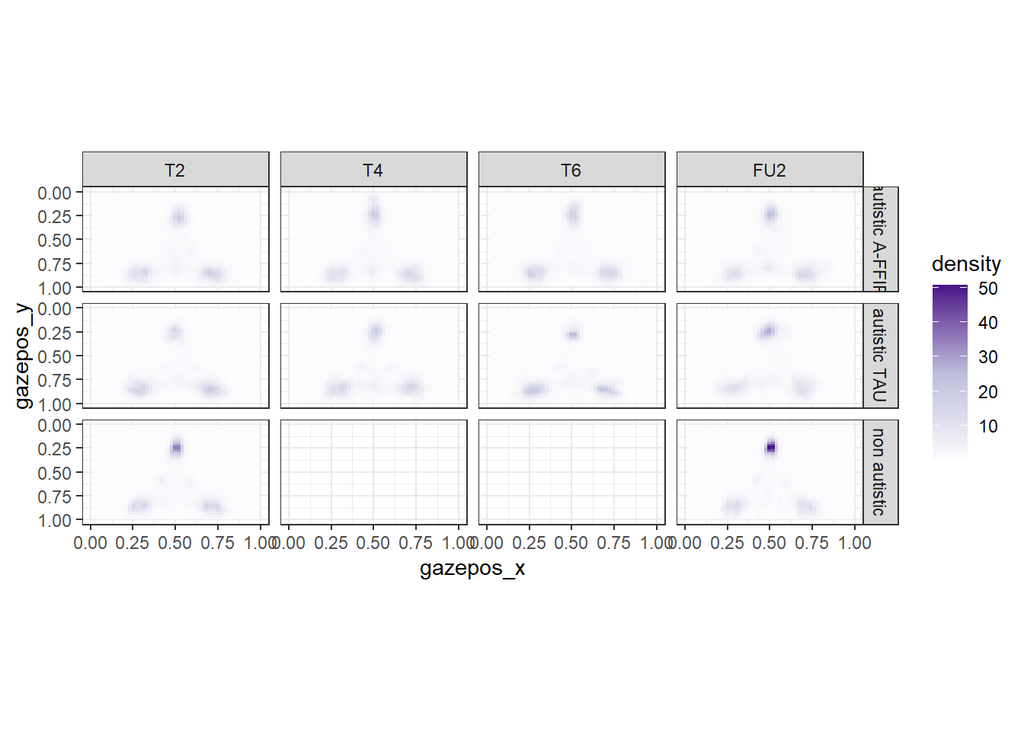

```r
    #heatmap between timepoints and groups for joint attention phase
    ggplot(df_jointatt[df_jointatt$ts_event>1000 &
                         df_jointatt$ts_event<2100,],aes(x=gazepos_x,y=gazepos_y))+
    #geom_hex(bins=100)+
    stat_density_2d(aes(fill=after_stat(density)), n=50, geom = "raster", contour = FALSE)+
    scale_fill_gradientn(colours=custom_palette)+
    ylim(1,0)+xlim(0,1)+coord_fixed(ratio = 9/16)+
    facet_grid(rndm~t)+theme_bw()
```

```r
# #before rja cueing onset
# ggplot(df_jointatt[df_jointatt$ts_event<1000,],aes(x=gazepos_x,y=gazepos_y))+
#   stat_density_2d(aes(fill=after_stat(density)), n=100, geom = "raster", contour = FALSE) +
#   #geom_hex(bins=100)+ # based on counts, so difficult to compare groups
#   scale_fill_gradientn(colours=custom_palette)+
#   ylim(1,0)+xlim(0,1)+coord_fixed(ratio = 9/16)+
#   facet_grid(rndm~t)+
#   labs(title='gaze behavior before RJA cueing onset (first 3.3s)')+
#   theme_void()
#
# #after RJA cueing onset
# ggplot(df_jointatt[df_jointatt$ts_event>1300 & df_jointatt$ts_event<1600,],aes(x=gazepos_x,y=gazepos_y))+
#   geom_hex(bins=100)+
#   #stat_density_2d(aes(fill=after_stat(density)), n=50, geom = "raster", contour = FALSE) +
#   scale_fill_gradientn(colours=custom_palette)+
#   ylim(1,0)+xlim(0,1)+coord_fixed(ratio = 9/16)+
#   facet_grid(rndm~t)+
#   labs(title='gaze behavior after RJA cueing onset (4.3 - 5.3s)')+
#   theme_void()
#
# #late RJA
# ggplot(df_jointatt[subsample & df_jointatt$ts_event>2000 & df_jointatt$ts_event<3000,],aes(x=gazepos_x,y=gazepos_y))+
#   geom_hex(bins=100)+
#   #stat_density_2d(aes(fill=after_stat(density)), n=50, geom = "raster", contour = FALSE) +
#   scale_fill_gradientn(colours=custom_palette)+
#   ylim(1,0)+xlim(0,1)+coord_fixed(ratio = 9/16)+
#   facet_wrap(~timepoint)+
#   labs(title='late RJA - (8.6 - 10s)')+
#   heme_void()
#
# #late RJA
# ggplot(df_jointatt[subsample & df_jointatt$ts_event>2700 & df_jointatt$ts_event<3300,],aes(x=gazepos_x,y=gazepos_y))+
#   geom_hex(bins=30)+
#   #stat_density_2d(aes(fill=after_stat(density)), n=50, geom = "raster", contour = FALSE) +
#   scale_fill_gradientn(colours=custom_palette)+
#   ylim(1,0)+xlim(0,1)+coord_fixed(ratio = 9/16)+
#   facet_wrap(~timepoint)+
#   labs(title='late RJA - (9 - 11s)')+
#   heme_void()
```

### 7.1.1 animate gaze behavior (gifs)

- render animation

```r
#transition variable in animation:
frame_rate<-300
df_jointatt$time_s<-with(df_jointatt,round(ts_event/frame_rate,1))

#BETWEEN GROUPS
animated_gaze<-ggplot(df_jointatt,aes(x=gazepos_x,y=gazepos_y))+
  stat_density_2d(aes(fill=after_stat(density)), n=50, geom = "raster", contour = FALSE) +
  #geom_bin_2d(bins=100)+
  #scale_fill_gradientn(colours=rev(rainbow(3)))+
  scale_fill_gradientn(colours = c("black","white","red","orange","yellow","green","blue"),
                         values = c(1.0,0.5,0.2,0.15,0.1,0.05,0))+
  ylim(1,0)+xlim(0,1)+coord_fixed(ratio = 9/16)+
  #facet_wrap(~timepoint)+
  facet_grid(position+rndm~t)+
  theme_bw()+
  theme(legend.position="none")+
  #animation specific
  #transition_time(time_s)+facet_wrap(~timepoint)
  transition_time(time_s)+
  ggtitle('Gaze behavior between groups','time: {frame_time}')

#save animation
gif_1<-animate(animated_gaze, duration = 10, fps = 10, width = 800, height = 800,
               renderer = gifski_renderer())
```

[output not shown]

[output cut: 46 more lines]

[output not shown]

```r
anim_save(file=paste0(project_path,'/output/gaze_animation_time_2ddensity_position300424.gif'),gif_1)


#ACROSS GROUPS - overall plot
animated_gaze<-ggplot(df_jointatt[df_jointatt$time_s>9 & df_jointatt$time_s<11,],
                      aes(x=gazepos_x,y=gazepos_y))+
  stat_density_2d(aes(fill=after_stat(density)), n=50, geom = "raster", contour = FALSE) +
  #geom_bin_2d(bins=100)+
  #scale_fill_gradientn(colours=rev(rainbow(3)))+
  scale_fill_gradientn(colours = c("black","white","red","orange","yellow","green","blue"),
                       values = c(1.0,0.5,0.2,0.15,0.1,0.05,0))+
  ylim(1,0)+xlim(0,1)+coord_fixed(ratio = 9/16)+
  #facet_wrap(~timepoint)+
  theme_bw()+
  theme(legend.position="none")+
  #animation specific
  #transition_time(time_s)+facet_wrap(~timepoint)
  transition_time(time_s)+
  ggtitle('Gaze behavior across groups','time: {frame_time}')

gif_1<-animate(animated_gaze, duration = 10, fps = 10, width = 800, height = 800,
               renderer = gifski_renderer())
```

[output not shown]

[output cut: 46 more lines]

[output not shown]

```r
anim_save(file=paste0(project_path,'/output/gaze_animation_las2s.gif'),gif_1)


#BETWEEN GROUPS - between target position
animated_gaze<-ggplot(df_jointatt,
                      aes(x=gazepos_x,y=gazepos_y))+
  stat_density_2d(aes(fill=after_stat(density)), n=50, geom = "raster", contour = FALSE) +
  scale_fill_gradientn(colours = c("black","white","red","orange","yellow","green","blue"),
                       values = c(1.0,0.5,0.2,0.15,0.1,0.05,0))+
  ylim(1,0)+xlim(0,1)+coord_fixed(ratio = 9/16)+
  facet_grid(position~rndm)+
  theme_bw()+
  theme(legend.position="none")+
  #animation specific
  transition_time(time_s)+
  ggtitle(label = 'Gaze behavior between groups within trials',
          subtitle = 'time: {frame_time}')

gif_1<-animate(animated_gaze, duration = 10, fps = 10, width = 1920, height = 1080,
               renderer = gifski_renderer())
```

[output not shown]

[output cut: 46 more lines]

[output not shown]

```r
anim_save(file=paste0(project_path,'/output/gaze_animation_by_group_and_target_position.gif'),gif_1)
```

#### 7.1.1.1 first 3 seconds

```r
knitr::include_graphics(paste0(project_path,'/gaze_animation_first3s.gif'), error = FALSE)
```

[figure not shown]

#### 7.1.1.2 next 6 seconds

```r
knitr::include_graphics(paste0(project_path,'/gaze_animation_next6s.gif'), error = FALSE)
```

[figure not shown]

#### 7.1.1.3 last 2 seconds

```r
knitr::include_graphics(paste0(project_path,'/gaze_animation_las2s.gif'), error = FALSE)
```

[figure not shown]

#### 7.1.1.4 gaze behavior between groups

```r
knitr::include_graphics(paste0(project_path,'/gaze_animation_time_2ddensity_position300424.gif'), error = FALSE)
```

[figure not shown]

## 7.2 reactive joint attention (RJA)

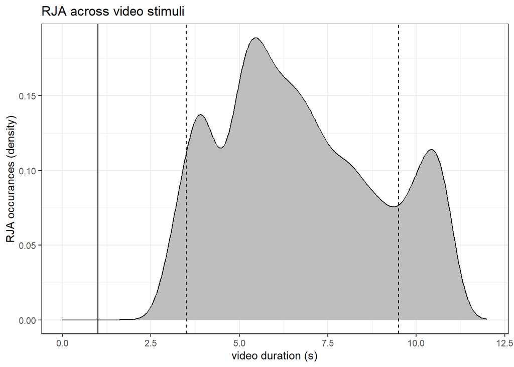

```r
##RJA
ggplot(df_jointatt,aes(x=rja_when/300))+
  geom_density(fill='grey',adjust=2)+
  labs(x='video duration (s)',y='RJA occurances (density)')+
  xlim(c(0,12))+
  geom_vline(xintercept=1)+geom_vline(xintercept=3.5,linetype='dashed')+
  geom_vline(xintercept=9.5,linetype='dashed')+
  labs(title='RJA across video stimuli')+
  theme_bw()
```

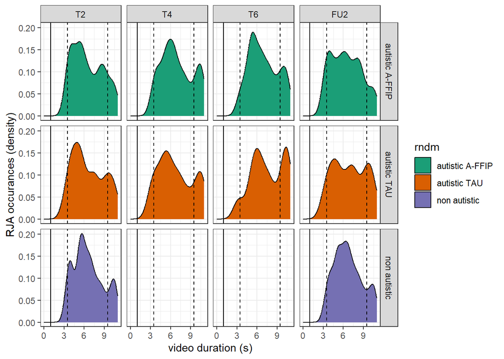

```r
##RJA between timepoints and groups
ggplot(df_jointatt,
       aes(x=rja_when/300,group=t,fill=rndm))+
  geom_density(adjust=2)+
  labs(x='video duration (s)',y='RJA occurances (density)')+
  xlim(c(0,11))+
  geom_vline(xintercept=1)+geom_vline(xintercept=3.5,linetype='dashed')+
  geom_vline(xintercept=9.5,linetype='dashed')+
  scale_fill_brewer(palette='Dark2')+
  facet_grid(rndm~t)+theme_bw()
```

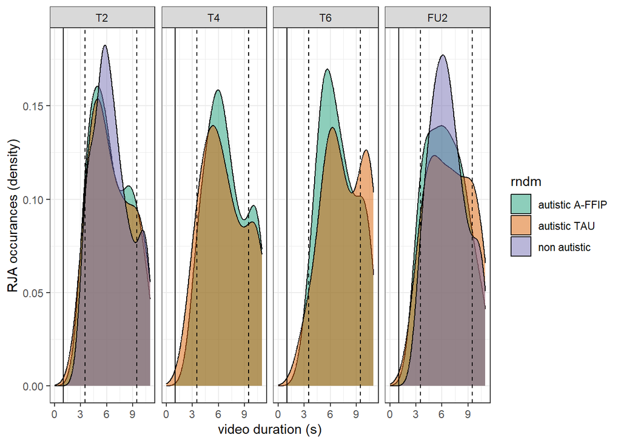

```r
# figure with overlapping plots
ggplot(df_jointatt,
       aes(x=rja_when/300,group=interaction(t,rndm),fill=rndm))+
  geom_density(adjust=3,alpha=0.5)+
  labs(x='video duration (s)',y='RJA occurances (density)')+
  xlim(c(0,11))+
  geom_vline(xintercept=1)+geom_vline(xintercept=3.5,linetype='dashed')+
  geom_vline(xintercept=9.5,linetype='dashed')+
  scale_fill_brewer(palette='Dark2')+
  facet_grid(.~t)+theme_bw()
```

```r
    # ##head gaze between timepoints
    # ggplot(df_jointatt,
    #        aes(x=gazehead_when/300,group=t,fill=rndm))+
    #   geom_density(adjust=2)+
    #   labs(x='video duration (s)',y='head gaze (density)')+
    #   xlim(c(0,11))+
    #   geom_vline(xintercept=1)+geom_vline(xintercept=4,linetype='dashed')+
    #   geom_vline(xintercept=10,linetype='dashed')+
    #   scale_fill_brewer(palette='Dark2')+
    #   facet_grid(rndm~t)+theme_bw()
    #
    # ##head gaze between timepoints
    # ggplot(df_jointatt,
    #        aes(x=gazetarget_when/300,group=t,fill=rndm))+
    #   geom_density(adjust=2)+
    #   labs(x='video duration (s)',y='target gaze (density)')+
    #   xlim(c(0,11))+
    #   geom_vline(xintercept=1)+geom_vline(xintercept=4,linetype='dashed')+
    #   geom_vline(xintercept=10,linetype='dashed')+
    #   scale_fill_brewer(palette='Dark2')+
    #   facet_grid(rndm~t)+theme_bw()
    #
    # ##RJA between conditions
    # ggplot(df_jointatt[!is.na(df_jointatt$gaze_top),],aes(x=ts_event,fill=gaze_top))+geom_bar(position = "fill")+
    #   labs(x='sample (1/300s)',y='proportion of all samples')+
    #   geom_vline(xintercept=450,lty=1,color='black')+
    #   geom_vline(xintercept=900,lty=2,color='blue')+
    #   geom_vline(xintercept=2700,lty=2,color='blue')+
    #   facet_grid(vars(position),vars(condition))+theme_bw()
```

## 7.3 social attention - gaze head

- firugre interpretation:
  - no differences in initial social attention before joint attention cueing
  - non-autistic more social attention during joint attention phase
  - A-FFIP versus TAU at T4 and T6 with more
  - A-FFIP versus TAU at follow-up with earlier socia attention during joint attention

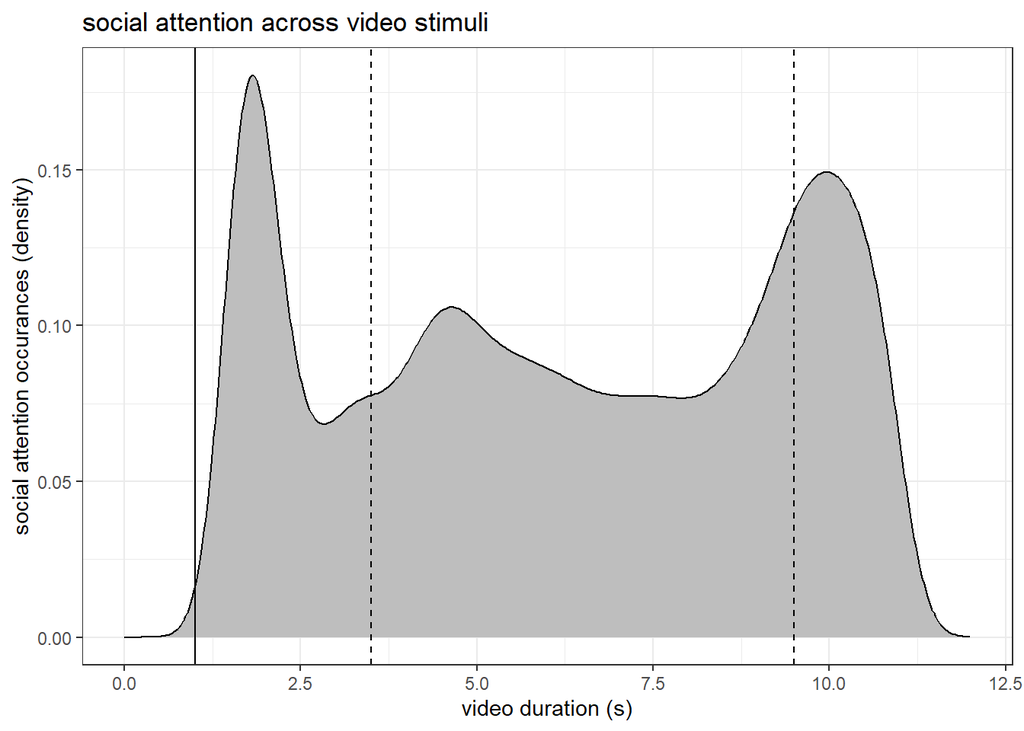

```r
##social attention across video stimuli
ggplot(df_jointatt,aes(x=gazehead_when/300))+
  geom_density(fill='grey',adjust=2)+
  labs(x='video duration (s)',y='social attention occurances (density)')+
  xlim(c(0,12))+
  geom_vline(xintercept=1)+geom_vline(xintercept=3.5,linetype='dashed')+
  geom_vline(xintercept=9.5,linetype='dashed')+
  labs(title='social attention across video stimuli')+
  theme_bw()
```

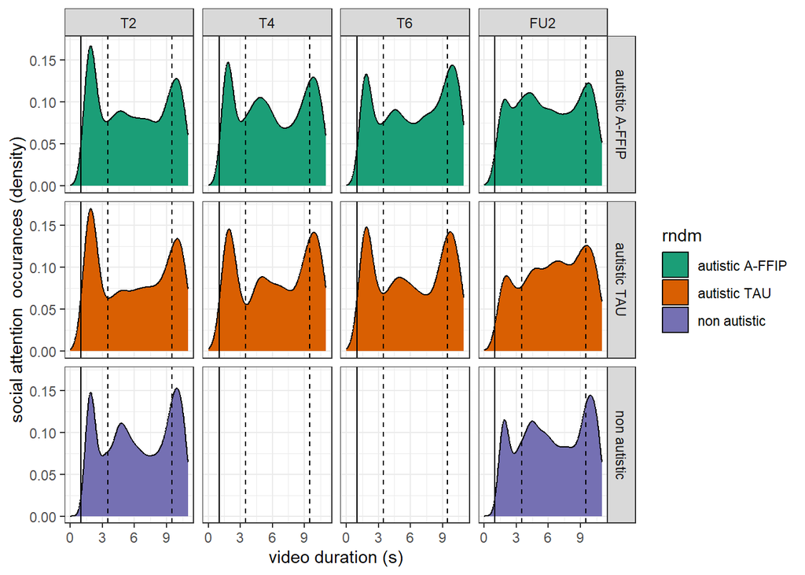

```r
##social attention between timepoints and groups
ggplot(df_jointatt,
       aes(x=gazehead_when/300,group=t,fill=rndm))+
  geom_density(adjust=2)+
  labs(x='video duration (s)',y='social attention  occurances (density)')+
  xlim(c(0,11))+
  geom_vline(xintercept=1)+geom_vline(xintercept=3.5,linetype='dashed')+
  geom_vline(xintercept=9.5,linetype='dashed')+
  scale_fill_brewer(palette='Dark2')+
  facet_grid(rndm~t)+theme_bw()
```

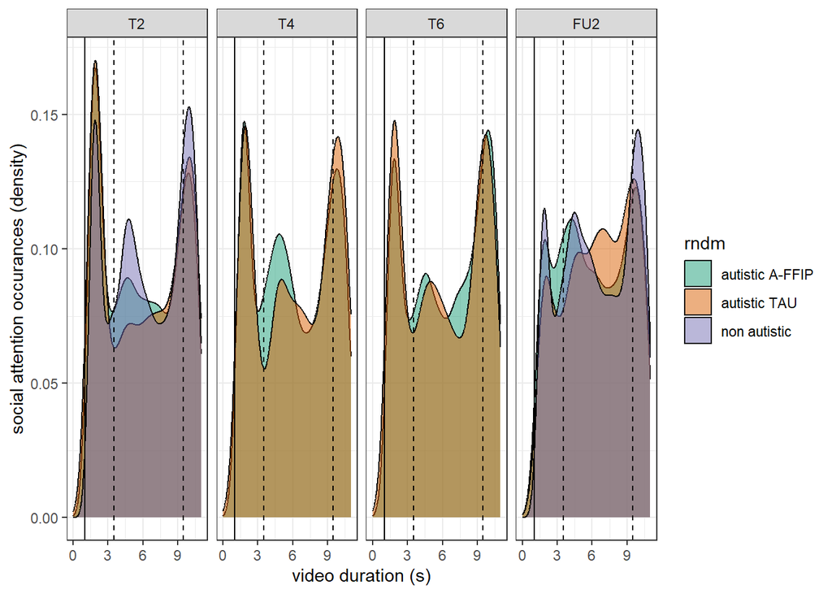

```r
# figure with overlapping plots
ggplot(df_jointatt,
       aes(x=gazehead_when/300,group=interaction(t,rndm),fill=rndm))+
  geom_density(adjust=2,alpha=0.5)+
  labs(x='video duration (s)',y='social attention occurances (density)')+
  xlim(c(0,11))+
  geom_vline(xintercept=1)+geom_vline(xintercept=3.5,linetype='dashed')+
  geom_vline(xintercept=9.5,linetype='dashed')+
  scale_fill_brewer(palette='Dark2')+
  facet_grid(.~t)+theme_bw()
```

## 7.4 baseline pupil size

- shows that BPS reflects arousal and not a luminance adaptation

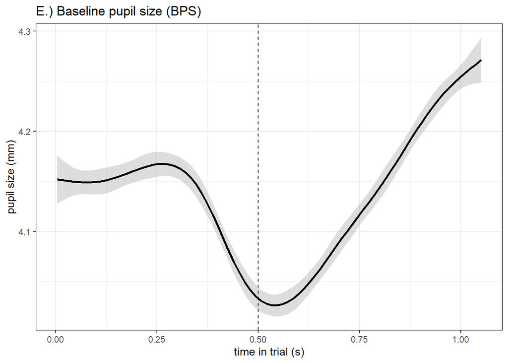

```r
##define percentage of data sampling for visualization
subsample<-sample(1:nrow(df_jointatt),nrow(df_jointatt)/sampling_factor)
df_jointatt_plot<-df_jointatt[subsample,]
#--> select 10% of data for faster plotting (faster rendering)

#select only attention grabber phase
df_jointatt_plot<-df_jointatt_plot[df_jointatt_plot$time_s<=1,]

## specific to groups
# ggplot(df_jointatt_plot,aes(x=ts_event/300,y=pd,
#                             group=rndm,color=rndm,fill=rndm))+
#   geom_smooth()+geom_vline(linetype=2,xintercept=0.5)+
#   labs(x='tme in trial (s)',y='pupil size (mm)')+
#   scale_fill_brewer(palette='Dark2')+ #custom color
#   scale_color_brewer(palette='Dark2')+ #custom color
#   labs(color='group',fill='group') #custom labels


ggplot(df_jointatt_plot,aes(x=ts_event/300,y=pd))+
  geom_smooth(color='black',fill='darkgrey')+
  geom_vline(linetype=2,xintercept=0.5)+
  labs(x='time in trial (s)',y='pupil size (mm)',title='E.) Baseline pupil size (BPS)')
```

## 7.5 stimulus-evoked pupillary response

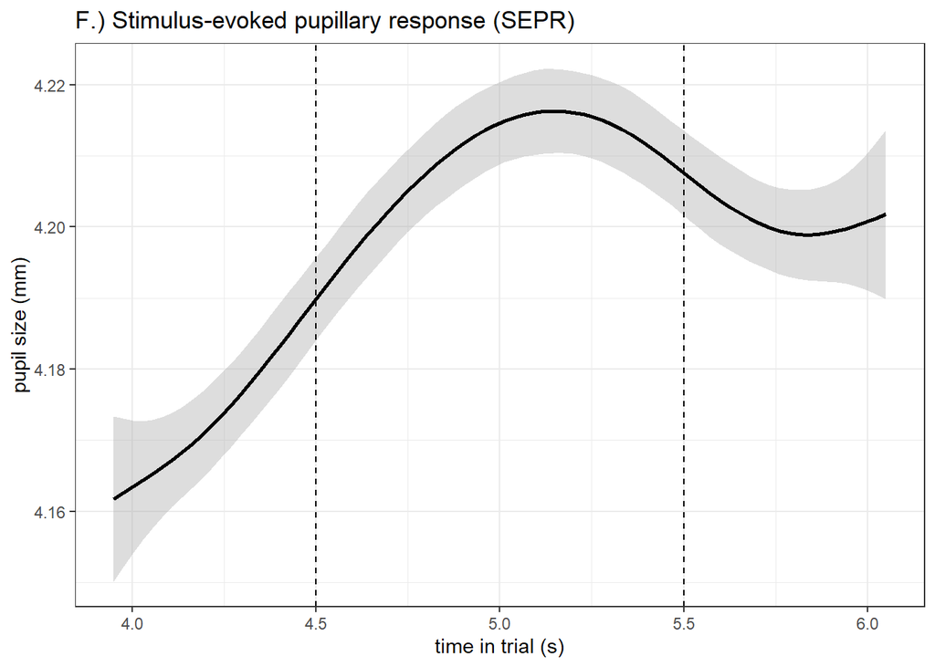

```r
##define percentage of data sampling for visualization
subsample<-sample(1:nrow(df_jointatt),nrow(df_jointatt)/sampling_factor)
df_jointatt_plot<-df_jointatt[subsample,]
#--> select 10% of data for faster plotting (faster rendering)

#select only gaze cued associated response
df_jointatt_plot<-df_jointatt_plot[df_jointatt_plot$time_s>=4 & df_jointatt_plot$time_s<=6,]

## group specific
# ggplot(df_jointatt_plot,aes(x=ts_event/300,y=pd,
#                             group=rndm,color=rndm,fill=rndm))+
#   geom_smooth(method="lm",formula=y ~ poly(x, 2, raw=TRUE))+
#   geom_vline(linetype=2,xintercept=c(4.5,5.5))+
#   labs(x='tme in trial (s)',y='pupil size (mm)')+
#   scale_fill_brewer(palette='Dark2')+ #custom color
#   scale_color_brewer(palette='Dark2')+ #custom color
#   labs(color='group',fill='group') #custom labels


ggplot(df_jointatt_plot,aes(x=ts_event/300,y=pd))+
  geom_smooth(color='black',fill='darkgrey')+
  geom_vline(linetype=2,xintercept=c(4.5,5.5))+
  labs(x='time in trial (s)',y='pupil size (mm)',title='F.) Stimulus-evoked pupillary response (SEPR)')
```

## 7.6 pupil dilation

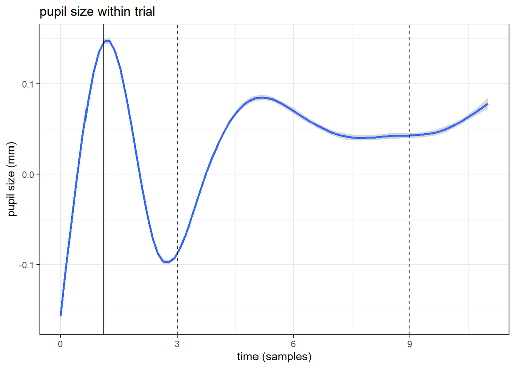

```r
##define percentage of data sampling for visualization
subsample<-sample(1:nrow(df_jointatt),nrow(df_jointatt)/sampling_factor)
#--> select 10% of data for faster plotting (faster rendering)


#visualize pupillary response progression (for INSAR 2023 abstract)
#pupil size progression - between conditions

#--> overall pupillary response
ggplot(df_jointatt[subsample,],aes(x=ts_event/300,y=rpd))+
  geom_smooth()+
  theme_bw()+
  labs(title='pupil size within trial',x='time (samples)',y='pupil size (mm)')+
  geom_vline(xintercept=1.1)+geom_vline(xintercept=3,linetype=2)+geom_vline(xintercept=9,linetype=2)
```

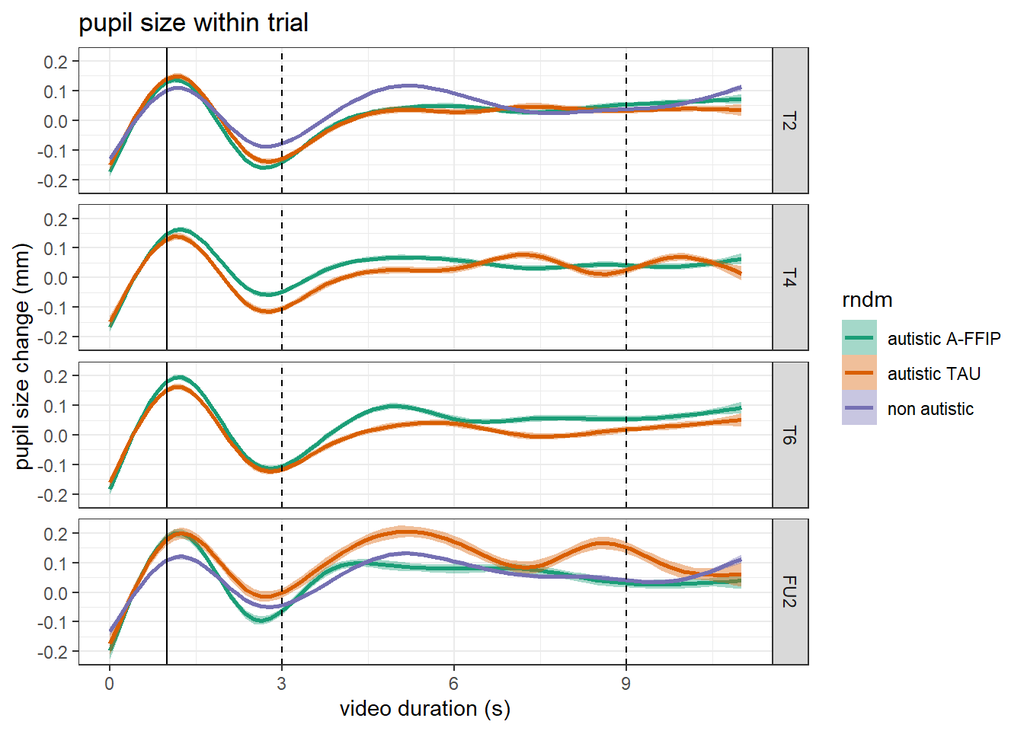

```r
  ###--> pupillary response is not a six degree polynomial

#--> between timepoints x groups
ggplot(df_jointatt[subsample,],aes(x=ts_event/300,y=rpd,group=rndm,color=rndm))+
  geom_smooth(aes(fill=rndm))+theme_bw()+
  labs(title='pupil size within trial',x='video duration (s)',y='pupil size change (mm)')+
  geom_vline(xintercept=1)+geom_vline(xintercept=3,linetype='dashed')+
  geom_vline(xintercept=9,linetype='dashed')+
  scale_fill_brewer(palette='Dark2')+
  scale_color_brewer(palette='Dark2')+
  facet_grid(t~.)
```

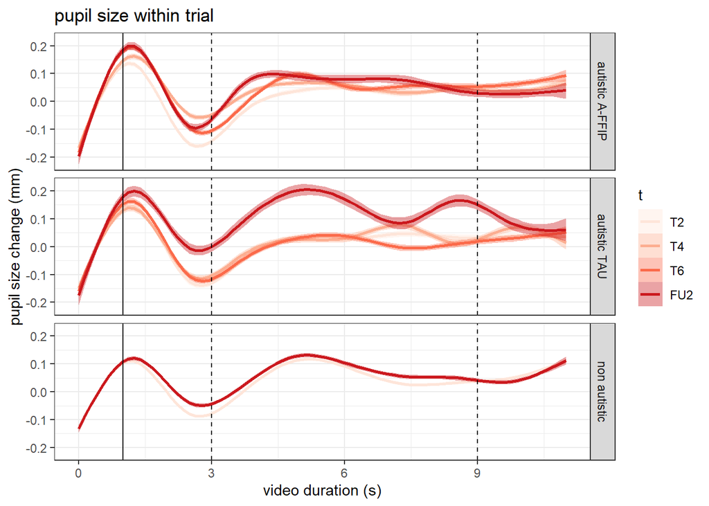

```r
## --> emphasize change within groups
ggplot(df_jointatt[subsample,],aes(x=ts_event/300,y=rpd,group=t,color=t))+
  geom_smooth(aes(fill=t))+theme_bw()+
  labs(title='pupil size within trial',x='video duration (s)',y='pupil size change (mm)')+
  geom_vline(xintercept=1)+geom_vline(xintercept=3,linetype='dashed')+
  geom_vline(xintercept=9,linetype='dashed')+
  scale_fill_brewer(palette='Reds')+
  scale_color_brewer(palette='Reds')+
  facet_grid(rndm~.)
```

```r
# #--> between condition
# ggplot(df_jointatt[subsample,],aes(x=ts_event/300,y=rpd,group=condition,color=condition))+
#   geom_smooth()+theme_bw()+labs(title='pupil size within trial',x='time (samples)',y='pupil size (mm)')+
#   geom_vline(xintercept=1)+geom_vline(xintercept=3,linetype='dashed')+scale_color_brewer(palette='Dark2')
#
# #--> between condition x timepoint
# ggplot(df_jointatt[subsample,],aes(x=ts_event,y=rpd,group=timepoint,color=timepoint))+
#   geom_smooth()+theme_bw()+labs(title='pupil size within trial',x='time (samples)',y='pupil size (mm)')+
#   geom_vline(xintercept=450)+geom_vline(xintercept=900)+facet_wrap(~condition)
#   #--> intense: only t2 has attenuated response / mild: K response is stronger than t2/t4/t6
#
# #-> condition x group
# ggplot(df_jointatt,aes(x=ts_event,y=rpd,group=interaction(condition,group),color=condition,linetype=group))+
#   geom_smooth(method='lm', formula = y ~ x + poly(x,6))+theme_bw()+labs(title='pupil size within trial',x='time (samples)',y='pupil size (mm)')+
#   geom_vline(xintercept=450)+geom_vline(xintercept=900)
```

# 8 correlation table

```r
res <- Hmisc::rcorr(as.matrix(df_et_agg[,names(df_et_agg) %in% c("baseline_pd",
                                                          "rpd_middle",
                                                          "rja_any",
                                                          "rja_duration",
                                                          "target_missed",
                                                          "no_data",
                                                          "fixation_duration",
                                                          "t_age",
                                                          "nonverbal_iq"
                                                          )]))

round(res$r,2)
round(res$P,2)

corrplot::corrplot(corr= res$r, p.mat= res$P, method = 'number',
                   type = "upper", order = "hclust",
                   sig.level = 0.001, insig = 'blank',
                   tl.col = "black", tl.srt = 45)
```

[output not shown]

# 9 data analysis

- overall findings: PERFORMANCE
  - rja likelihood within groups: A-FFIp and non-autistic improve with likelihood, but not TAU
  - rja likelihood: A-FFIP has a higher likelihood than TAU at FU, no difference at baseline
  - rja likelihood between autism groups: A-FFIp improves T2-T6, but TAU does not
- overall findings: NEUROPHYSIOLOGICAL RESPONSE
  - higher baseline PD is associated with LOWER pupillary response, RJA duration and likelihood
  - at FU: TAU with higher baseline PD than A-FFIP and non autistic, no difference at baseline
  - pupillary response increases RJA likelihood (and head attention)
  - higher pupillary response in TAU during FU compared to A-FFIP/non-autistic, not at baseline
    - this difference is not there for early and late pupillary response
- Cascades: change in RJA likelihood from T2 to T6 is assoicated with change in SRS score

## 9.1 task condition effects

### 9.1.1 task condition effects

- no effects
- thus, not considered as covariates or fixed effects

```r
glmm<-glmer(rja_any~condition+
            (1|pic)+(1|index_trial),data=df_trial[df_trial$t %in% c('T2','FU2'),],family='binomial')

anova(glmm)
```

```
## Analysis of Variance Table
##           npar  Sum Sq Mean Sq F value
## condition    3 0.32336 0.10779  0.1078
```

```r
glmm<-glmer(rja_any~stimulus+
            (1|pic)+(1|index_trial),data=df_trial[df_trial$t %in% c('T2','FU2'),],family='binomial')

anova(glmm)
```

```
## Analysis of Variance Table
##          npar Sum Sq Mean Sq F value
## stimulus    3 1.0481 0.34937  0.3494
```

```r
glmm<-glmer(rja_any~position+
            (1|pic)+(1|index_trial),data=df_trial[df_trial$t %in% c('T2','FU2'),],family='binomial')

anova(glmm)
```

```
## Analysis of Variance Table
##          npar   Sum Sq  Mean Sq F value
## position    1 0.090985 0.090985   0.091
```

### 9.1.2 task effects on baseline PD

- covariates of task properites, participant characteristics have no effect
- only a higher missing data is associated with higher baseline PD –> use data quality as covariate in models on arousal?

```r
lmm<-lmer(baseline_pd~condition+stimulus+position+ #task properties
                  t_age+gender+baseline_nonverbal_iq+ #participant covariates
                  no_data+fixation_duration+ #data quality
                  (1|pic)+(1|index_trial),data=df_trial[df_trial$t %in% c('T2','FU2'),])

anova(lmm)
```

```
## Type III Analysis of Variance Table with Satterthwaite's method
##                        Sum Sq Mean Sq NumDF   DenDF F value   Pr(>F)
## condition             0.30626 0.10209     3 1113.76  0.7467  0.52432
## stimulus              0.83419 0.27806     3 1113.98  2.0339  0.10741
## position              0.07643 0.07643     1 1110.76  0.5590  0.45481
## t_age                 0.01392 0.01392     1 1134.64  0.1018  0.74975
## gender                0.24883 0.24883     1  104.25  1.8201  0.18023
## baseline_nonverbal_iq 0.37908 0.37908     1  114.16  2.7728  0.09862 .
## no_data               2.48295 2.48295     1 1182.79 18.1618 2.19e-05 ***
## fixation_duration     0.31043 0.31043     1 1175.91  2.2707  0.13211
## ---
## Signif. codes:  0 '***' 0.001 '**' 0.01 '*' 0.05 '.' 0.1 ' ' 1
```

```r
fixef(lmm)
```

```
##           (Intercept)         conditionmild      conditionneutral
##          3.9837277110         -0.0305974262         -0.0228741500
##        conditionpoint        stimulusflower        stimulusrabbit
##          0.0095916126         -0.0512283838         -0.0549744057
##         stimulustruck  positiontarget_right                 t_age
##          0.0007695396         -0.0161783048          0.0002596092
##               genderm baseline_nonverbal_iq               no_data
##          0.1311198419         -0.0027438434          0.6454429358
##     fixation_duration
##          0.0202132262
```

## 9.2 RJA association with ESCS data

- small positive association of RJA in eye-tracking and behavioral observation of RJA

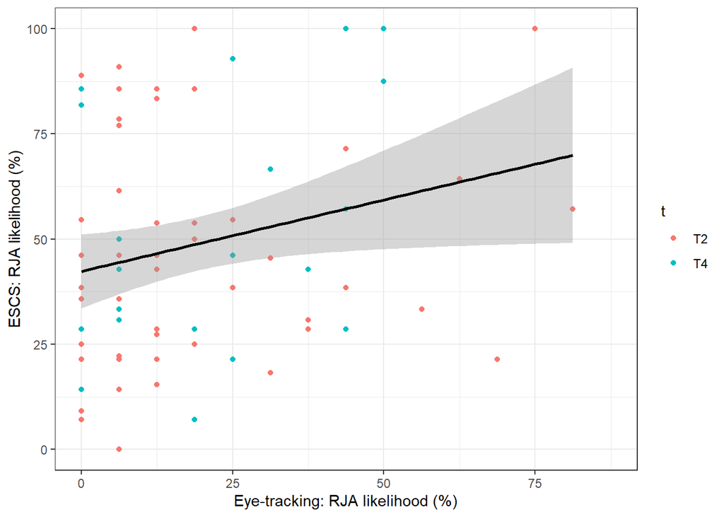

```r
# df_escs<-merge(dplyr::select(df_sample,Total_RJA,pic),
#             dplyr::select(df_et_agg[df_et_agg$t=='T2',],pic,rja_any),by='pic')
#
#
# df_escs<-merge(dplyr::select(demogr,Total_RJA,ID_Studie,t),
#             dplyr::select(df_et_agg[df_et_agg$t %in% c('T2','T4'),],pic,rja_any,t),
#             by.x=list('ID_Studie','t'),
#             by.y=list('pic','t'))

df_escs_1<-dplyr::select(demogr,Total_RJA,ID_Studie,t)
df_escs_1$pic<-as.factor(df_escs_1$ID_Studie)
df_escs_2<-dplyr::select(df_et_agg[df_et_agg$t %in% c('T2','T4'),],pic,rja_any,t)

df_escs<-merge(df_escs_1,df_escs_2,
               by=c('pic','t'))

ggplot(df_escs,aes(x=rja_any/16*100,y=Total_RJA))+geom_point(aes(color=t))+geom_smooth(method='lm',color='black')+
  labs(x='Eye-tracking: RJA likelihood (%)',y='ESCS: RJA likelihood (%)')
```

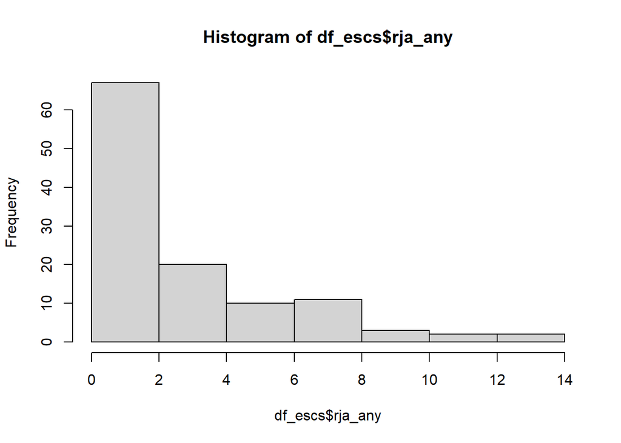

```r
hist(df_escs$rja_any)
```

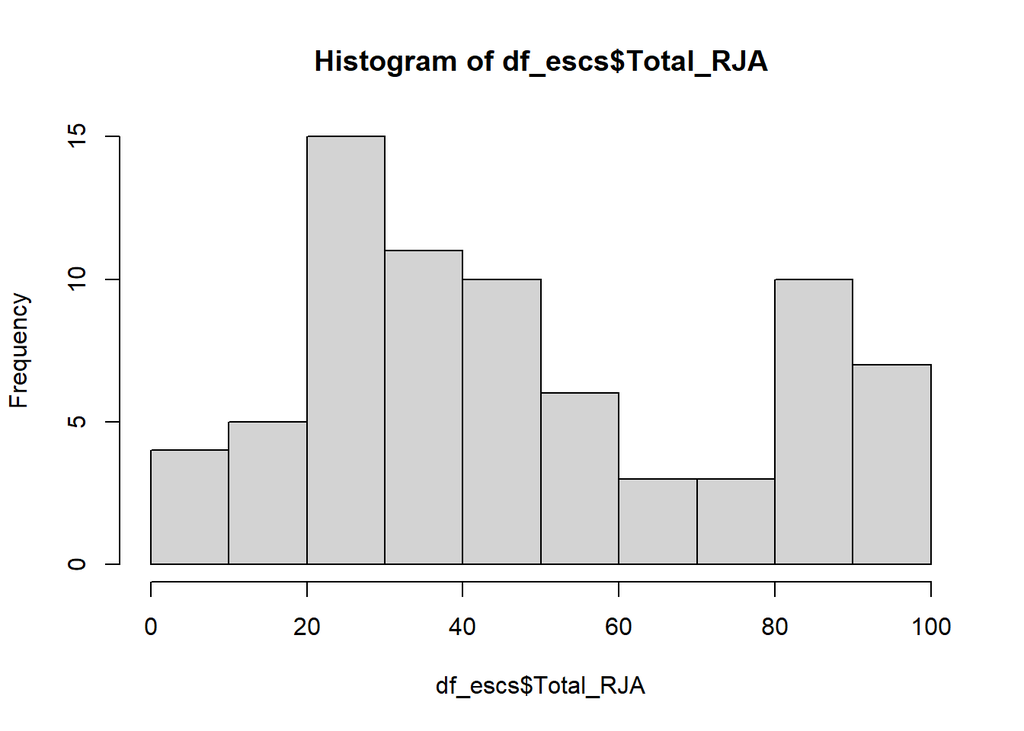

```r
hist(df_escs$Total_RJA)
```

```r
#table(df_escs$Total_RJA)

#cor.test(df_escs$rja_any,df_escs$Total_RJA,method='pearson')

lmm<-lmer(scale(rja_any)~scale(Total_RJA)+(1|pic),df_escs)
summary(lmm)
```

```
## Linear mixed model fit by REML. t-tests use Satterthwaite's method [
## lmerModLmerTest]
## Formula: scale(rja_any) ~ scale(Total_RJA) + (1 | pic)
##    Data: df_escs
##
## REML criterion at convergence: 203.4
##
## Scaled residuals:
##     Min      1Q  Median      3Q     Max
## -1.4411 -0.5201 -0.1752  0.4502  2.0191
##
## Random effects:
##  Groups   Name        Variance Std.Dev.
##  pic      (Intercept) 0.5508   0.7421
##  Residual             0.4152   0.6444
## Number of obs: 74, groups:  pic, 57
##
## Fixed effects:
##                  Estimate Std. Error       df t value Pr(>|t|)
## (Intercept)       0.03143    0.12525 52.59020   0.251   0.8029
## scale(Total_RJA)  0.28579    0.12440 59.44727   2.297   0.0251 *
## ---
## Signif. codes:  0 '***' 0.001 '**' 0.01 '*' 0.05 '.' 0.1 ' ' 1
##
## Correlation of Fixed Effects:
##             (Intr)
## scl(Tt_RJA) 0.035
```

```r
confint(lmm, 'scale(Total_RJA)', level=0.95)
```

```
## Computing profile confidence intervals ...
```

```
##                       2.5 %    97.5 %
## scale(Total_RJA) 0.04206712 0.5304401
```

## 9.3 RJA likelihood

- developmental model - between 3 groups:
  - A-FFIP has a higher likelihood than TAU at FU, no difference at T2
  - –> within groups: A-FFIp and non-autistic improve with likelihood, but not TAU
  - non autistic still with higher likelihood
- intervention model - between autism groups
- A-FFIP group improves from T2-T6 but not the TAU group

### 9.3.1 treatment model - in autism groups

- increase of RJA likelihood from baseline to end-of-treatment in A-FFIp but not TAU

```r
### in autism groups ####

glmm<-glmer(rja_any~t*rndm+
            (1|pic)+(1|index_trial),data=df_trial[df_trial$t %in% c('T2','T6') &
                                                    df_trial$rndm!='non autistic',],family='binomial')
#model fit
r2_nakagawa(glmm)
```

```
## # R2 for Mixed Models
##
##   Conditional R2: 0.373
##      Marginal R2: 0.049
```

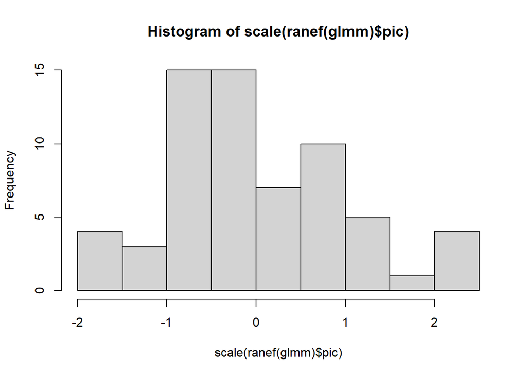

```r
#random effect distribution
hist(scale(ranef(glmm)$pic),10)
```

```r
#planned contrasts
confint(contrast(emmeans(glmm,~t|rndm,type = "response"),'revpairwise'))
```

```
## rndm = autistic A-FFIP:
##  contrast odds.ratio    SE  df asymp.LCL asymp.UCL
##  T6 / T2        1.52 0.278 Inf      1.07      2.18
##
## rndm = autistic TAU:
##  contrast odds.ratio    SE  df asymp.LCL asymp.UCL
##  T6 / T2        1.49 0.334 Inf      0.96      2.31
##
## Confidence level used: 0.95
## Intervals are back-transformed from the log odds ratio scale
```

```r
emmeans(glmm,~t|rndm,type = "response")
```

```
## rndm = autistic A-FFIP:
##  t    prob     SE  df asymp.LCL asymp.UCL
##  T2 0.1550 0.0361 Inf    0.0965     0.240
##  T6 0.2185 0.0473 Inf    0.1398     0.325
##
## rndm = autistic TAU:
##  t    prob     SE  df asymp.LCL asymp.UCL
##  T2 0.0691 0.0206 Inf    0.0381     0.122
##  T6 0.0995 0.0297 Inf    0.0546     0.175
##
## Confidence level used: 0.95
## Intervals are back-transformed from the logit scale
```

```r
contrast(emmeans(glmm,~t|rndm,type = "response"),'revpairwise',adjust='none')
```

```
## rndm = autistic A-FFIP:
##  contrast odds.ratio    SE  df null z.ratio p.value
##  T6 / T2        1.52 0.278 Inf    1   2.307  0.0211
##
## rndm = autistic TAU:
##  contrast odds.ratio    SE  df null z.ratio p.value
##  T6 / T2        1.49 0.334 Inf    1   1.779  0.0752
##
## Tests are performed on the log odds ratio scale
```

```r
###--> improvement of RJA likelihood in A-FFIP group

#comparsion at timepoints
contrast(emmeans(glmm,~rndm+t,type = "response"),'pairwise')[c(1,6),]
```

```
## Note: adjust = "tukey" was changed to "sidak"
## because "tukey" is only appropriate for one set of pairwise comparisons
```

```
##  contrast                               odds.ratio    SE  df null z.ratio
##  (autistic A-FFIP T2) / autistic TAU T2       2.47 0.932 Inf    1   2.403
##  (autistic A-FFIP T6) / autistic TAU T6       2.53 0.984 Inf    1   2.385
##  p.value
##   0.0322
##   0.0339
##
## P value adjustment: sidak method for 2 tests
## Tests are performed on the log odds ratio scale
```

```r
confint(contrast(emmeans(glmm,~rndm+t,type = "response"),'pairwise',adjust='none'))[c(1,6),]
```

```
##  contrast                               odds.ratio    SE  df asymp.LCL
##  (autistic A-FFIP T2) / autistic TAU T2       2.47 0.932 Inf      1.18
##  (autistic A-FFIP T6) / autistic TAU T6       2.53 0.984 Inf      1.18
##  asymp.UCL
##       5.18
##       5.42
##
## Confidence level used: 0.95
## Intervals are back-transformed from the log odds ratio scale
```

### 9.3.2 developmental model - in all three groups

- between 3 groups:
  - A-FFIP has a higher likelihood than TAU at FU, no difference at T2
  - non autistics still with higher likelihood
  - within groups: A-FFIp and non-autistic improve with likelihood, but not TAU

```r
#any
glmm<-glmer(rja_any~t*rndm+
            (1|pic)+(1|index_trial),data=df_trial[df_trial$t %in% c('T2','FU2'),],family='binomial')

#model fit
r2_nakagawa(glmm)
```

```
## # R2 for Mixed Models
##
##   Conditional R2: 0.513
##      Marginal R2: 0.169
```

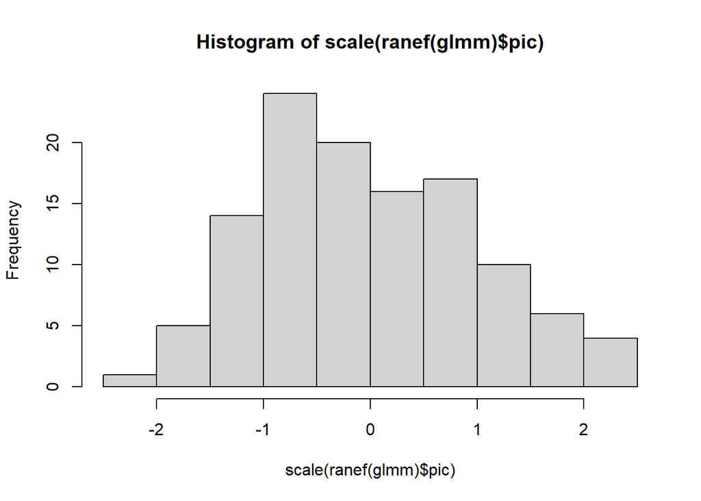

```r
#random effect distribution --> saved as supplement
hist(scale(ranef(glmm)$pic),10)
```

```r
#means at baseline
emmeans(glmm,~rndm|t,type = "response")
```

```
## t = T2:
##  rndm              prob     SE  df asymp.LCL asymp.UCL
##  autistic A-FFIP 0.1379 0.0385 Inf    0.0782     0.232
##  autistic TAU    0.0594 0.0198 Inf    0.0305     0.112
##  non autistic    0.3767 0.0633 Inf    0.2627     0.506
##
## t = FU2:
##  rndm              prob     SE  df asymp.LCL asymp.UCL
##  autistic A-FFIP 0.2757 0.0756 Inf    0.1534     0.444
##  autistic TAU    0.0937 0.0350 Inf    0.0441     0.188
##  non autistic    0.5884 0.0706 Inf    0.4467     0.717
##
## Confidence level used: 0.95
## Intervals are back-transformed from the logit scale
```

```r
#planned contrasts
confint(contrast(emmeans(glmm,~t|rndm,type = "response"),'revpairwise'))
```

```
## rndm = autistic A-FFIP:
##  contrast odds.ratio    SE  df asymp.LCL asymp.UCL
##  FU2 / T2       2.38 0.643 Inf     1.402      4.04
##
## rndm = autistic TAU:
##  contrast odds.ratio    SE  df asymp.LCL asymp.UCL
##  FU2 / T2       1.64 0.511 Inf     0.887      3.02
##
## rndm = non autistic:
##  contrast odds.ratio    SE  df asymp.LCL asymp.UCL
##  FU2 / T2       2.37 0.387 Inf     1.717      3.26
##
## Confidence level used: 0.95
## Intervals are back-transformed from the log odds ratio scale
```

```r
contrast(emmeans(glmm,~t|rndm,type = "response"),'revpairwise')
```

```
## rndm = autistic A-FFIP:
##  contrast odds.ratio    SE  df null z.ratio p.value
##  FU2 / T2       2.38 0.643 Inf    1   3.210  0.0013
##
## rndm = autistic TAU:
##  contrast odds.ratio    SE  df null z.ratio p.value
##  FU2 / T2       1.64 0.511 Inf    1   1.576  0.1150
##
## rndm = non autistic:
##  contrast odds.ratio    SE  df null z.ratio p.value
##  FU2 / T2       2.37 0.387 Inf    1   5.264  <.0001
##
## Tests are performed on the log odds ratio scale
```

```r
# comparsion at timepoints
contrast(emmeans(glmm,~rndm+t,type = "response"),'pairwise',adjust='none')[13,]
```

```
##  contrast                                 odds.ratio   SE  df null z.ratio
##  (autistic A-FFIP FU2) / autistic TAU FU2       3.68 1.85 Inf    1   2.596
##  p.value
##   0.0094
##
## Tests are performed on the log odds ratio scale
```

```r
confint(contrast(emmeans(glmm,~rndm+t,type = "response"),'pairwise',adjust='none'))[13,]
```

```
##  contrast                                 odds.ratio   SE  df asymp.LCL
##  (autistic A-FFIP FU2) / autistic TAU FU2       3.68 1.85 Inf      1.38
##  asymp.UCL
##       9.86
##
## Confidence level used: 0.95
## Intervals are back-transformed from the log odds ratio scale
```

```r
contrast(emmeans(glmm,~rndm+t,type = "response"),'pairwise',adjust='none')[c(2,6)]
```

```
##  contrast                               odds.ratio    SE  df null z.ratio
##  (autistic A-FFIP T2) / non autistic T2      0.265 0.091 Inf    1  -3.864
##  autistic TAU T2 / non autistic T2           0.105 0.039 Inf    1  -6.051
##  p.value
##   0.0001
##   <.0001
##
## Tests are performed on the log odds ratio scale
```

```r
confint(contrast(emmeans(glmm,~rndm+t,type = "response"),'pairwise',adjust='none')[c(2,6)])
```

```
##  contrast                               odds.ratio    SE  df asymp.LCL
##  (autistic A-FFIP T2) / non autistic T2      0.265 0.091 Inf    0.1349
##  autistic TAU T2 / non autistic T2           0.105 0.039 Inf    0.0503
##  asymp.UCL
##      0.519
##      0.217
##
## Confidence level used: 0.95
## Intervals are back-transformed from the log odds ratio scale
```

```r
contrast(emmeans(glmm,~rndm+t,type = "response"),'pairwise',adjust='none')[c(14,15)]
```

```
##  contrast                                 odds.ratio     SE  df null z.ratio
##  (autistic A-FFIP FU2) / non autistic FU2     0.2663 0.1099 Inf    1  -3.206
##  autistic TAU FU2 / non autistic FU2          0.0723 0.0321 Inf    1  -5.921
##  p.value
##   0.0013
##   <.0001
##
## Tests are performed on the log odds ratio scale
```

```r
confint(contrast(emmeans(glmm,~rndm+t,type = "response"),'pairwise',adjust='none')[c(14,15)])
```

```
##  contrast                                 odds.ratio     SE  df asymp.LCL
##  (autistic A-FFIP FU2) / non autistic FU2     0.2663 0.1099 Inf    0.1186
##  autistic TAU FU2 / non autistic FU2          0.0723 0.0321 Inf    0.0303
##  asymp.UCL
##      0.598
##      0.172
##
## Confidence level used: 0.95
## Intervals are back-transformed from the log odds ratio scale
```

### 9.3.3 RJA baseline as predictor

- baseline RJA likelihood is investigated as predictor of RJA at end-of-treatment and follow-up
- is only relevant in the developmental model and specific to the non-autistic group

```r
# df_et_agg_rja<-df_et_agg[,names(df_et_agg) %in% c('pic','t','rja_any','rndm')]
# df_et_agg_rja<-reshape2::dcast(df_et_agg_rja,pic+rndm~t)
# lm<-lm(FU2~T2*rndm,data=df_et_agg_rja)
# anova(lm)
#
# df_et_agg_rja<-df_trial[,names(df_trial) %in% c('pic','t','rja_any','rndm')]
# df_et_agg_rja<-reshape2::dcast(df_et_agg_rja,pic+rndm~t,value.var='rja_any',fun.aggregate=sum)
# lm<-lm(FU2~T2*rndm,data=df_et_agg_rja)
# anova(lm)


#TEST IN GLMM

# ## random intercept model limited to one random intercept, choose best:
# glmm1<-glmer(T6~T2*rndm+(1|pic),data=df_et_agg_rja[df_et_agg_rja$rndm!='non autistic',],family='binomial')
# glmm2<-glmer(T6~T2*rndm+(1|index_trial),data=df_et_agg_rja[df_et_agg_rja$rndm!='non autistic',],family='binomial')
# anova(glmm1,glmm2)
# r2_nakagawa(glmm1)
# r2_nakagawa(glmm2)
# ###--> pic as random intercept has superior fit

#shape data
df_et_agg_rja<-df_trial[,names(df_trial) %in% c('pic','t','rja_any','rndm','index_trial')]
df_et_agg_rja<-reshape2::dcast(df_et_agg_rja,pic+rndm+index_trial~t,value.var='rja_any',fun.aggregate=any)

#intervention model
glmm<-glmer(T6~T2*rndm+(1|pic),data=df_et_agg_rja[df_et_agg_rja$rndm!='non autistic',],family='binomial')
r2_nakagawa(glmm)
```

```
## # R2 for Mixed Models
##
##   Conditional R2: 0.552
##      Marginal R2: 0.049
```

```r
confint(contrast(emmeans(glmm,~T2,type = "response"),'revpairwise'))
```

```
## NOTE: Results may be misleading due to involvement in interactions
```

```
##  contrast     odds.ratio    SE  df asymp.LCL asymp.UCL
##  TRUE / FALSE       1.38 0.373 Inf     0.817      2.35
##
## Results are averaged over the levels of: rndm
## Confidence level used: 0.95
## Intervals are back-transformed from the log odds ratio scale
```

```r
confint(contrast(emmeans(glmm,~T2|rndm,type = "response"),'revpairwise'))
```

```
## rndm = autistic A-FFIP:
##  contrast     odds.ratio    SE  df asymp.LCL asymp.UCL
##  TRUE / FALSE       1.29 0.421 Inf     0.679      2.44
##
## rndm = autistic TAU:
##  contrast     odds.ratio    SE  df asymp.LCL asymp.UCL
##  TRUE / FALSE       1.49 0.633 Inf     0.647      3.42
##
## Confidence level used: 0.95
## Intervals are back-transformed from the log odds ratio scale
```

```r
#development model
glmm<-glmer(FU2~T2*rndm+(1|pic),data=df_et_agg_rja,family='binomial')
r2_nakagawa(glmm)
```

```
## # R2 for Mixed Models
##
##   Conditional R2: 0.875
##      Marginal R2: 0.085
```

```r
confint(contrast(emmeans(glmm,~T2|rndm,type = "response"),'revpairwise'))
```

```
## rndm = autistic A-FFIP:
##  contrast     odds.ratio    SE  df asymp.LCL asymp.UCL
##  TRUE / FALSE      0.503 0.247 Inf     0.192      1.32
##
## rndm = autistic TAU:
##  contrast     odds.ratio    SE  df asymp.LCL asymp.UCL
##  TRUE / FALSE      2.256 1.434 Inf     0.649      7.84
##
## rndm = non autistic:
##  contrast     odds.ratio    SE  df asymp.LCL asymp.UCL
##  TRUE / FALSE      1.841 0.534 Inf     1.043      3.25
##
## Confidence level used: 0.95
## Intervals are back-transformed from the log odds ratio scale
```

### 9.3.4 aggregated model

- used to compare to previous literature with paradigm of Senju & Csibra 2008

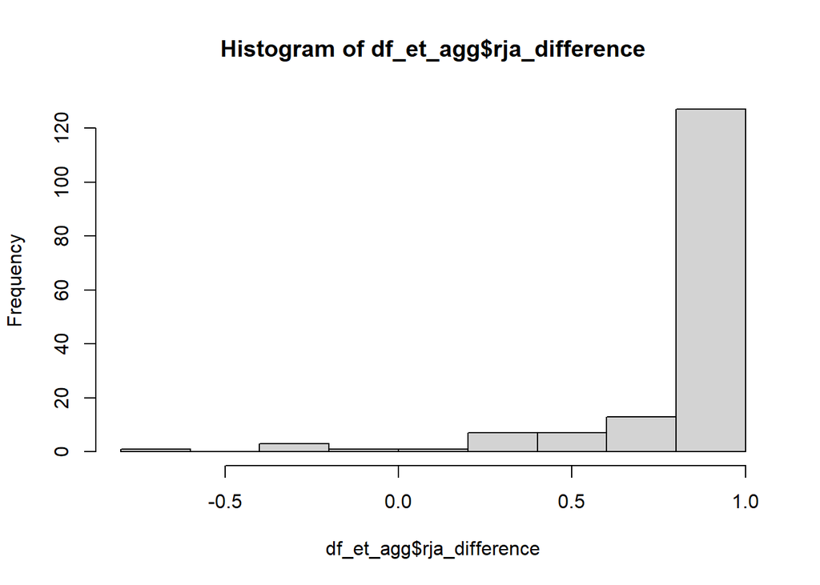

```r
df_et_agg$rja_difference<-with(df_et_agg,(rja_any-target_missed)/(rja_any+target_missed))
df_et_agg$rja_difference<-with(df_et_agg,ifelse((rja_any+target_missed)<3,NA,rja_difference))
hist(df_et_agg$rja_difference)
```

```r
require(rstatix)
lm<-lm(rja_difference~t*rndm,data=df_et_agg[df_et_agg$t %in% c('T2','FU2'),])
anova(lm)
```

```
## Analysis of Variance Table
##
## Response: rja_difference
##           Df Sum Sq  Mean Sq F value Pr(>F)
## t          1 0.1298 0.129776  1.6003 0.2091
## rndm       2 0.1166 0.058325  0.7192 0.4899
## t:rndm     2 0.1926 0.096321  1.1878 0.3096
## Residuals 91 7.3795 0.081094
```

```r
lm<-anova_test(df_et_agg[df_et_agg$t %in% c('T2','FU2'),],rja_difference~t*rndm,wid=pic,within=t,type=3)
get_anova_table(lm)
```

```
## ANOVA Table (type III tests)
##
##   Effect DFn DFd     F     p p<.05   ges
## 1      t   1  91 0.870 0.353       0.009
## 2   rndm   2  91 0.221 0.802       0.005
## 3 t:rndm   2  91 1.188 0.310       0.025
```

```r
lm<-aov(rja_difference~t*rndm,data=df_et_agg[df_et_agg$t %in% c('T2','FU2'),])
anova(lm)
```

```
## Analysis of Variance Table
##
## Response: rja_difference
##           Df Sum Sq  Mean Sq F value Pr(>F)
## t          1 0.1298 0.129776  1.6003 0.2091
## rndm       2 0.1166 0.058325  0.7192 0.4899
## t:rndm     2 0.1926 0.096321  1.1878 0.3096
## Residuals 91 7.3795 0.081094
```

```r
lm<-aov(rja_difference~t*rndm,data=df_et_agg[df_et_agg$t %in% c('T2','T6') & df_et_agg$rndm!='non autistic',])
anova(lm)
```

```
## Analysis of Variance Table
##
## Response: rja_difference
##           Df Sum Sq  Mean Sq F value Pr(>F)
## t          1 0.0838 0.083810  1.0563 0.3089
## rndm       1 0.1145 0.114492  1.4430 0.2352
## t:rndm     1 0.1169 0.116897  1.4734 0.2304
## Residuals 51 4.0464 0.079341
```

```r
lm<-aov(rja_any~t*rndm,data=df_et_agg[df_et_agg$t %in% c('T2','FU2'),])
anova(lm)
```

```
## Analysis of Variance Table
##
## Response: rja_any
##            Df  Sum Sq Mean Sq F value    Pr(>F)
## t           1   79.17   79.17  4.6830   0.03203 *
## rndm        2  704.84  352.42 20.8457 1.013e-08 ***
## t:rndm      2    9.53    4.76  0.2817   0.75487
## Residuals 151 2552.83   16.91
## ---
## Signif. codes:  0 '***' 0.001 '**' 0.01 '*' 0.05 '.' 0.1 ' ' 1
```

```r
###--> not seen in aggregated data

lm<-lm(rja_any~t*rndm,data=df_et_agg[df_et_agg$t %in% c('T2','T6') & df_et_agg$rndm!='non autistic',])
anova(lm)
```

```
## Analysis of Variance Table
##
## Response: rja_any
##            Df  Sum Sq Mean Sq F value  Pr(>F)
## t           1   22.92  22.923  2.2157 0.13967
## rndm        1   42.86  42.860  4.1427 0.04438 *
## t:rndm      1    0.27   0.266  0.0257 0.87295
## Residuals 103 1065.63  10.346
## ---
## Signif. codes:  0 '***' 0.001 '**' 0.01 '*' 0.05 '.' 0.1 ' ' 1
```

## 9.4 gaze head duration as social attention

```r
#association of social attention and RJA likelihood
df_trial$gazeduration_head_z<-scale(df_trial$gazeduration_head)
glmm<-glmer(rja_any~gazeduration_head_z+
            (1|pic)+(1|index_trial),data=df_trial,family='binomial')

r2_nakagawa(glmm)
```

```
## # R2 for Mixed Models
##
##   Conditional R2: 0.301
##      Marginal R2: 0.134
```

```r
summary(glmm)
```

```
## Generalized linear mixed model fit by maximum likelihood (Laplace
##   Approximation) [glmerMod]
##  Family: binomial  ( logit )
## Formula: rja_any ~ gazeduration_head_z + (1 | pic) + (1 | index_trial)
##    Data: df_trial
##
##      AIC      BIC   logLik deviance df.resid
##   2683.0   2705.9  -1337.5   2675.0     2244
##
## Scaled residuals:
##     Min      1Q  Median      3Q     Max
## -3.8957 -0.7289  0.3033  0.7323  3.0163
##
## Random effects:
##  Groups      Name        Variance Std.Dev.
##  pic         (Intercept) 0.6695   0.8183
##  index_trial (Intercept) 0.1200   0.3464
## Number of obs: 2248, groups:  pic, 118; index_trial, 16
##
## Fixed effects:
##                     Estimate Std. Error z value Pr(>|z|)
## (Intercept)          0.11799    0.13023   0.906    0.365
## gazeduration_head_z  0.79349    0.06648  11.936   <2e-16 ***
## ---
## Signif. codes:  0 '***' 0.001 '**' 0.01 '*' 0.05 '.' 0.1 ' ' 1
##
## Correlation of Fixed Effects:
##             (Intr)
## gzdrtn_hd_z 0.065
```

```r
cbind(round(fixef(glmm)['gazeduration_head_z'],2),
      round(confint(glmm,parm = 'gazeduration_head_z'),2))
```

```
## Computing profile confidence intervals ...
```

```
##                          2.5 % 97.5 %
## gazeduration_head_z 0.79  0.66   0.93
```

```r
#intervention model - 2 groups
lmm<-lmer(gazeduration_head~t*rndm+
            (1|pic)+(1|index_trial),data=df_trial[df_trial$t %in% c('T2','T6') &
                                                    df_trial$rndm!='non autistic',])

r2_nakagawa(lmm)
```

```
## # R2 for Mixed Models
##
##   Conditional R2: 0.486
##      Marginal R2: 0.007
```

```r
confint(contrast(emmeans(lmm,~t|rndm),'revpairwise'))
```

```
## rndm = autistic A-FFIP:
##  contrast estimate    SE  df lower.CL upper.CL
##  T6 - T2     0.140 0.110 767  -0.0769    0.357
##
## rndm = autistic TAU:
##  contrast estimate    SE  df lower.CL upper.CL
##  T6 - T2    -0.125 0.139 768  -0.3972    0.148
##
## Degrees-of-freedom method: kenward-roger
## Confidence level used: 0.95
```

```r
#development model - 3 groups
lmm<-lmer(gazeduration_head_z~t*rndm+
            (1|pic)+(1|index_trial),data=df_trial[df_trial$t %in% c('T2','FU2'),])

r2_nakagawa(lmm)
```

```
## # R2 for Mixed Models
##
##   Conditional R2: 0.505
##      Marginal R2: 0.118
```

```r
emmeans(lmm,~t|rndm)
```

```
## rndm = autistic A-FFIP:
##  t   emmean    SE  df lower.CL upper.CL
##  T2  -0.381 0.129 126  -0.6370   -0.124
##  FU2 -0.154 0.154 223  -0.4580    0.150
##
## rndm = autistic TAU:
##  t   emmean    SE  df lower.CL upper.CL
##  T2  -0.412 0.143 145  -0.6944   -0.129
##  FU2 -0.276 0.179 289  -0.6279    0.076
##
## rndm = non autistic:
##  t   emmean    SE  df lower.CL upper.CL
##  T2   0.129 0.102 107  -0.0728    0.331
##  FU2  0.546 0.109 136   0.3302    0.762
##
## Degrees-of-freedom method: kenward-roger
## Confidence level used: 0.95
```

```r
contrast(emmeans(lmm,~t|rndm),'revpairwise')
```

```
## rndm = autistic A-FFIP:
##  contrast estimate     SE   df t.ratio p.value
##  FU2 - T2    0.227 0.1083 1401   2.093  0.0366
##
## rndm = autistic TAU:
##  contrast estimate     SE   df t.ratio p.value
##  FU2 - T2    0.136 0.1460 1340   0.929  0.3529
##
## rndm = non autistic:
##  contrast estimate     SE   df t.ratio p.value
##  FU2 - T2    0.417 0.0641 1398   6.501  <.0001
##
## Degrees-of-freedom method: kenward-roger
```

```r
confint(contrast(emmeans(lmm,~t|rndm),'revpairwise'))
```

```
## rndm = autistic A-FFIP:
##  contrast estimate     SE   df lower.CL upper.CL
##  FU2 - T2    0.227 0.1083 1401   0.0142    0.439
##
## rndm = autistic TAU:
##  contrast estimate     SE   df lower.CL upper.CL
##  FU2 - T2    0.136 0.1460 1340  -0.1507    0.422
##
## rndm = non autistic:
##  contrast estimate     SE   df lower.CL upper.CL
##  FU2 - T2    0.417 0.0641 1398   0.2909    0.542
##
## Degrees-of-freedom method: kenward-roger
## Confidence level used: 0.95
```

```r
emmeans(lmm,~t|rndm)
```

```
## rndm = autistic A-FFIP:
##  t   emmean    SE  df lower.CL upper.CL
##  T2  -0.381 0.129 126  -0.6370   -0.124
##  FU2 -0.154 0.154 223  -0.4580    0.150
##
## rndm = autistic TAU:
##  t   emmean    SE  df lower.CL upper.CL
##  T2  -0.412 0.143 145  -0.6944   -0.129
##  FU2 -0.276 0.179 289  -0.6279    0.076
##
## rndm = non autistic:
##  t   emmean    SE  df lower.CL upper.CL
##  T2   0.129 0.102 107  -0.0728    0.331
##  FU2  0.546 0.109 136   0.3302    0.762
##
## Degrees-of-freedom method: kenward-roger
## Confidence level used: 0.95
```

```r
###--> increase of social attention in non-autistic and autistic A-FFIP across timepoints

confint(contrast(emmeans(lmm,~rndm|t),'revpairwise'))
```

```
## t = T2:
##  contrast                         estimate    SE  df lower.CL upper.CL
##  autistic TAU - (autistic A-FFIP)  -0.0308 0.183 127   -0.466    0.404
##  non autistic - (autistic A-FFIP)   0.5100 0.153 113    0.146    0.874
##  non autistic - autistic TAU        0.5408 0.165 125    0.149    0.932
##
## t = FU2:
##  contrast                         estimate    SE  df lower.CL upper.CL
##  autistic TAU - (autistic A-FFIP)  -0.1218 0.228 252   -0.660    0.416
##  non autistic - (autistic A-FFIP)   0.7000 0.179 188    0.277    1.123
##  non autistic - autistic TAU        0.8218 0.201 232    0.349    1.295
##
## Degrees-of-freedom method: kenward-roger
## Confidence level used: 0.95
## Conf-level adjustment: tukey method for comparing a family of 3 estimates
```

## 9.5 baseline pupil size

- outcome measure: pupil size within first 500ms of video stimulus
- higher baseline PD is associated with lower RJA likelihood and social attention
- at FU: higher baseline PD in TAU compared to A-FFIp and non-autistic, but not at baseline

### 9.5.1 effects on RJA measures

- higher baseline PD is associated with lower RJA likelihood and social attention

```r
df_trial$baseline_pd_z<-scale(df_trial$baseline_pd)
glmm<-glmer(rja_any~baseline_pd_z+
            (1|pic)+(1|index_trial),data=df_trial,family='binomial')

summary(glmm)
```

```
## Generalized linear mixed model fit by maximum likelihood (Laplace
##   Approximation) [glmerMod]
##  Family: binomial  ( logit )
## Formula: rja_any ~ baseline_pd_z + (1 | pic) + (1 | index_trial)
##    Data: df_trial
##
##      AIC      BIC   logLik deviance df.resid
##   3337.9   3362.2  -1665.0   3329.9     3158
##
## Scaled residuals:
##     Min      1Q  Median      3Q     Max
## -2.9668 -0.5896 -0.3099  0.6312  4.7334
##
## Random effects:
##  Groups      Name        Variance Std.Dev.
##  pic         (Intercept) 2.134    1.4607
##  index_trial (Intercept) 0.261    0.5109
## Number of obs: 3162, groups:  pic, 120; index_trial, 16
##
## Fixed effects:
##               Estimate Std. Error z value Pr(>|z|)
## (Intercept)   -1.04712    0.19492  -5.372 7.79e-08 ***
## baseline_pd_z -0.32385    0.06738  -4.807 1.53e-06 ***
## ---
## Signif. codes:  0 '***' 0.001 '**' 0.01 '*' 0.05 '.' 0.1 ' ' 1
##
## Correlation of Fixed Effects:
##             (Intr)
## baseln_pd_z -0.003
```

```r
cbind(round(fixef(glmm)['baseline_pd_z'],2),
      round(confint(glmm,parm = 'baseline_pd_z'),2))
```

```
## Computing profile confidence intervals ...
```

```
##                     2.5 % 97.5 %
## baseline_pd_z -0.32 -0.46  -0.19
```

```r
# lmm<-lmer(scale(gazeduration_head)~baseline_pd_z+
#             (1|pic)+(1|index_trial),data=df_trial)
#
# r2_nakagawa(lmm)
#
#
# summary(lmm)
#
# cbind(round(fixef(lmm)['baseline_pd_z'],2),
#       round(confint(lmm,parm = 'baseline_pd_z'),2))
#
```

### 9.5.2 intervention model - autism groups

- decrease of baseline PD in TAU

```r
#intervention model
lmm<-lmer(baseline_pd_z~t*rndm+
            (1|pic)+(1|index_trial),data=df_trial[df_trial$t %in% c('T2','T6') &
                                                    df_trial$rndm!='non autistic',])

r2_nakagawa(lmm)
```

```
## # R2 for Mixed Models
##
##   Conditional R2: 0.625
##      Marginal R2: 0.008
```

```r
contrast(emmeans(lmm,~t|rndm),'revpairwise')
```

```
## rndm = autistic A-FFIP:
##  contrast estimate     SE   df t.ratio p.value
##  T6 - T2  -0.00953 0.0566 1136  -0.169  0.8662
##
## rndm = autistic TAU:
##  contrast estimate     SE   df t.ratio p.value
##  T6 - T2  -0.17458 0.0633 1134  -2.756  0.0059
##
## Degrees-of-freedom method: kenward-roger
```

```r
confint(contrast(emmeans(lmm,~t|rndm),'revpairwise'))
```

```
## rndm = autistic A-FFIP:
##  contrast estimate     SE   df lower.CL upper.CL
##  T6 - T2  -0.00953 0.0566 1136   -0.121   0.1014
##
## rndm = autistic TAU:
##  contrast estimate     SE   df lower.CL upper.CL
##  T6 - T2  -0.17458 0.0633 1134   -0.299  -0.0503
##
## Degrees-of-freedom method: kenward-roger
## Confidence level used: 0.95
```

```r
contrast(emmeans(lmm,~rndm|t),'revpairwise')
```

```
## t = T2:
##  contrast                         estimate    SE   df t.ratio p.value
##  autistic TAU - (autistic A-FFIP)   0.2194 0.207 65.9   1.060  0.2929
##
## t = T6:
##  contrast                         estimate    SE   df t.ratio p.value
##  autistic TAU - (autistic A-FFIP)   0.0544 0.210 69.2   0.259  0.7962
##
## Degrees-of-freedom method: kenward-roger
```

```r
confint(contrast(emmeans(lmm,~rndm|t),'revpairwise'))
```

```
## t = T2:
##  contrast                         estimate    SE   df lower.CL upper.CL
##  autistic TAU - (autistic A-FFIP)   0.2194 0.207 65.9   -0.194    0.633
##
## t = T6:
##  contrast                         estimate    SE   df lower.CL upper.CL
##  autistic TAU - (autistic A-FFIP)   0.0544 0.210 69.2   -0.364    0.473
##
## Degrees-of-freedom method: kenward-roger
## Confidence level used: 0.95
```

### 9.5.3 developmental model - between three groups

- at FU: higher baseline PD in TAU compared to A-FFIp and non-autistic, but not at baseline

```r
lmm<-lmer(baseline_pd_z~t*rndm+
            (1|pic)+(1|index_trial),data=df_trial[df_trial$t %in% c('T2','FU2'),])

r2_nakagawa(lmm)
```

```
## # R2 for Mixed Models
##
##   Conditional R2: 0.642
##      Marginal R2: 0.033
```

```r
contrast(emmeans(lmm,~t|rndm),'revpairwise')
```

```
## rndm = autistic A-FFIP:
##  contrast estimate     SE   df t.ratio p.value
##  FU2 - T2   -0.276 0.0797 1865  -3.469  0.0005
##
## rndm = autistic TAU:
##  contrast estimate     SE   df t.ratio p.value
##  FU2 - T2    0.141 0.0973 1887   1.451  0.1469
##
## rndm = non autistic:
##  contrast estimate     SE   df t.ratio p.value
##  FU2 - T2   -0.161 0.0474 1826  -3.396  0.0007
##
## Degrees-of-freedom method: kenward-roger
```

```r
confint(contrast(emmeans(lmm,~t|rndm),'revpairwise'))
```

```
## rndm = autistic A-FFIP:
##  contrast estimate     SE   df lower.CL upper.CL
##  FU2 - T2   -0.276 0.0797 1865  -0.4326   -0.120
##
## rndm = autistic TAU:
##  contrast estimate     SE   df lower.CL upper.CL
##  FU2 - T2    0.141 0.0973 1887  -0.0496    0.332
##
## rndm = non autistic:
##  contrast estimate     SE   df lower.CL upper.CL
##  FU2 - T2   -0.161 0.0474 1826  -0.2541   -0.068
##
## Degrees-of-freedom method: kenward-roger
## Confidence level used: 0.95
```

```r
contrast(emmeans(lmm,~rndm|t),'pairwise')
```

```
## t = T2:
##  contrast                         estimate    SE  df t.ratio p.value
##  (autistic A-FFIP) - autistic TAU  -0.2002 0.199 120  -1.006  0.5746
##  (autistic A-FFIP) - non autistic   0.1365 0.174 117   0.784  0.7137
##  autistic TAU - non autistic        0.3367 0.181 117   1.861  0.1548
##
## t = FU2:
##  contrast                         estimate    SE  df t.ratio p.value
##  (autistic A-FFIP) - autistic TAU  -0.6178 0.221 175  -2.801  0.0156
##  (autistic A-FFIP) - non autistic   0.0212 0.187 154   0.113  0.9930
##  autistic TAU - non autistic        0.6390 0.197 163   3.235  0.0042
##
## Degrees-of-freedom method: kenward-roger
## P value adjustment: tukey method for comparing a family of 3 estimates
```

```r
confint(contrast(emmeans(lmm,~rndm|t),'pairwise'))
```

```
## t = T2:
##  contrast                         estimate    SE  df lower.CL upper.CL
##  (autistic A-FFIP) - autistic TAU  -0.2002 0.199 120  -0.6727   0.2722
##  (autistic A-FFIP) - non autistic   0.1365 0.174 117  -0.2769   0.5498
##  autistic TAU - non autistic        0.3367 0.181 117  -0.0928   0.7662
##
## t = FU2:
##  contrast                         estimate    SE  df lower.CL upper.CL
##  (autistic A-FFIP) - autistic TAU  -0.6178 0.221 175  -1.1392  -0.0964
##  (autistic A-FFIP) - non autistic   0.0212 0.187 154  -0.4225   0.4649
##  autistic TAU - non autistic        0.6390 0.197 163   0.1718   1.1061
##
## Degrees-of-freedom method: kenward-roger
## Confidence level used: 0.95
## Conf-level adjustment: tukey method for comparing a family of 3 estimates
```

## 9.6 pupillary response

- measures:
  - rpd_early<- mean 1-2 seconds
  - rpd_middle<- mean 4,5-5.5 seconds
  - rpd_late<-mean 10-11 seconds
- higher baseline PD is strongly associated with lower pupillary response
- pupillary response increases RJA likelihood and head attention
- higher pupillary response in TAU during FU compared to A-FFIp and non-autistic, not at baseline
  - this difference is not there for early and late pupillary response

### 9.6.1 task effects on pupillary response (RPD)

- rabbit is associated with stronger pupillary response

```r
lmm<-lmer(rpd_middle~condition+stimulus+position+
                  (1|pic)+(1|index_trial),data=df_trial[df_trial$t %in% c('T2','FU2'),])

anova(lmm)
```

```
## Type III Analysis of Variance Table with Satterthwaite's method
##            Sum Sq Mean Sq NumDF  DenDF F value  Pr(>F)
## condition 0.15036 0.05012     3 1641.8  0.3180 0.81240
## stimulus  1.46027 0.48676     3 1634.3  3.0881 0.02625 *
## position  0.15347 0.15347     1 1640.3  0.9737 0.32392
## ---
## Signif. codes:  0 '***' 0.001 '**' 0.01 '*' 0.05 '.' 0.1 ' ' 1
```

```r
contrast(emmeans(lmm,~stimulus),'pairwise')
```

```
##  contrast        estimate     SE   df t.ratio p.value
##  ball - flower   -0.03206 0.0273 1637  -1.174  0.6431
##  ball - rabbit   -0.03789 0.0268 1636  -1.413  0.4914
##  ball - truck     0.03496 0.0271 1640   1.288  0.5707
##  flower - rabbit -0.00584 0.0270 1640  -0.216  0.9964
##  flower - truck   0.06701 0.0273 1644   2.455  0.0676
##  rabbit - truck   0.07285 0.0268 1644   2.715  0.0338
##
## Results are averaged over the levels of: condition, position
## Degrees-of-freedom method: kenward-roger
## P value adjustment: tukey method for comparing a family of 4 estimates
```

### 9.6.2 RPD effects on RJA

- pupillary response increases RJA likelihood

```r
df_trial$rpd_middle_z<-scale(df_trial$rpd_middle)
glmm<-glmer(rja_any~rpd_middle_z+
            (1|pic)+(1|index_trial),data=df_trial[df_trial$t %in% c('T2','FU2'),],family='binomial')

summary(glmm)
```

```
## Generalized linear mixed model fit by maximum likelihood (Laplace
##   Approximation) [glmerMod]
##  Family: binomial  ( logit )
## Formula: rja_any ~ rpd_middle_z + (1 | pic) + (1 | index_trial)
##    Data: df_trial[df_trial$t %in% c("T2", "FU2"), ]
##
##      AIC      BIC   logLik deviance df.resid
##   2076.6   2098.4  -1034.3   2068.6     1742
##
## Scaled residuals:
##     Min      1Q  Median      3Q     Max
## -3.2116 -0.6494 -0.3436  0.7308  3.4087
##
## Random effects:
##  Groups      Name        Variance Std.Dev.
##  pic         (Intercept) 1.8450   1.3583
##  index_trial (Intercept) 0.3008   0.5485
## Number of obs: 1746, groups:  pic, 118; index_trial, 16
##
## Fixed effects:
##              Estimate Std. Error z value Pr(>|z|)
## (Intercept)   -0.7770     0.2014  -3.857 0.000115 ***
## rpd_middle_z   0.1314     0.0641   2.051 0.040310 *
## ---
## Signif. codes:  0 '***' 0.001 '**' 0.01 '*' 0.05 '.' 0.1 ' ' 1
##
## Correlation of Fixed Effects:
##             (Intr)
## rpd_middl_z -0.014
```

```r
cbind(round(fixef(glmm)['rpd_middle_z'],2),
      round(confint(glmm,parm = 'rpd_middle_z'),2))
```

```
## Computing profile confidence intervals ...
```

```
##                   2.5 % 97.5 %
## rpd_middle_z 0.13     0   0.26
```

### 9.6.3 RPD effect by baseline pupil size

-strong negative association

```r
lmm<-lmer(scale(rpd_middle)~baseline_pd_z+
            (1|pic)+(1|index_trial),data=df_trial)

summary(lmm)
```

```
## Linear mixed model fit by REML. t-tests use Satterthwaite's method [
## lmerModLmerTest]
## Formula: scale(rpd_middle) ~ baseline_pd_z + (1 | pic) + (1 | index_trial)
##    Data: df_trial
##
## REML criterion at convergence: 6415.6
##
## Scaled residuals:
##     Min      1Q  Median      3Q     Max
## -7.7373 -0.5938 -0.0277  0.6164  3.9208
##
## Random effects:
##  Groups      Name        Variance Std.Dev.
##  pic         (Intercept) 0.540395 0.7351
##  index_trial (Intercept) 0.004134 0.0643
##  Residual                0.504497 0.7103
## Number of obs: 2797, groups:  pic, 120; index_trial, 16
##
## Fixed effects:
##                 Estimate Std. Error         df t value Pr(>|t|)
## (Intercept)      0.04328    0.07091  111.60418    0.61    0.543
## baseline_pd_z   -0.88299    0.02001 1862.60395  -44.12   <2e-16 ***
## ---
## Signif. codes:  0 '***' 0.001 '**' 0.01 '*' 0.05 '.' 0.1 ' ' 1
##
## Correlation of Fixed Effects:
##             (Intr)
## baseln_pd_z -0.012
```

```r
cbind(round(fixef(lmm)['baseline_pd_z'],2),
      round(confint(lmm,parm = 'baseline_pd_z'),2))
```

```
## Computing profile confidence intervals ...
```

```
##                     2.5 % 97.5 %
## baseline_pd_z -0.88 -0.92  -0.84
```

```r
r2_nakagawa(lmm)
```

```
## # R2 for Mixed Models
##
##   Conditional R2: 0.721
##      Marginal R2: 0.420
```

### 9.6.4 RPD effect on head gaze

- higher pupillary response associated with head attention
- probably by measurement effects

```r
lmm<-lmer(gazeduration_head~rpd_middle+
            (1|pic),data=df_trial)

anova(lmm)
```

```
## Type III Analysis of Variance Table with Satterthwaite's method
##            Sum Sq Mean Sq NumDF DenDF F value    Pr(>F)
## rpd_middle 46.439  46.439     1  1912  26.646 2.698e-07 ***
## ---
## Signif. codes:  0 '***' 0.001 '**' 0.01 '*' 0.05 '.' 0.1 ' ' 1
```

```r
fixef(lmm)
```

```
## (Intercept)  rpd_middle
##   2.2425171   0.4100195
```

```r
lmm<-glmer(rja_any~gazeduration_head*rpd_middle+
            (1|pic),data=df_trial,family='binomial')

anova(lmm)
```

```
## Analysis of Variance Table
##                              npar  Sum Sq Mean Sq  F value
## gazeduration_head               1 158.522 158.522 158.5217
## rpd_middle                      1   2.377   2.377   2.3772
## gazeduration_head:rpd_middle    1   1.225   1.225   1.2253
```

```r
fixef(lmm)
```

```
##                  (Intercept)            gazeduration_head
##                  -1.07336480                   0.49506005
##                   rpd_middle gazeduration_head:rpd_middle
##                   0.40424358                  -0.08793138
```

### 9.6.5 RPD - two group, RCT analysis

- no effect

```r
lmm<-lmer(rpd_middle_z~t*rndm+
            (1|pic)+(1|index_trial),data=df_trial[df_trial$t %in% c('T2','T6') &
                                                    df_trial$rndm!='non autistic',])
r2_nakagawa(lmm)
```

```
## # R2 for Mixed Models
##
##   Conditional R2: 0.119
##      Marginal R2: 0.001
```

```r
contrast(emmeans(lmm,~t|rndm),'revpairwise')
```

```
## rndm = autistic A-FFIP:
##  contrast estimate     SE   df t.ratio p.value
##  T6 - T2   0.08500 0.0831  968   1.023  0.3067
##
## rndm = autistic TAU:
##  contrast estimate     SE   df t.ratio p.value
##  T6 - T2  -0.00208 0.0934 1005  -0.022  0.9822
##
## Degrees-of-freedom method: kenward-roger
```

```r
confint(contrast(emmeans(lmm,~t|rndm),'revpairwise'))
```

```
## rndm = autistic A-FFIP:
##  contrast estimate     SE   df lower.CL upper.CL
##  T6 - T2   0.08500 0.0831  968  -0.0781    0.248
##
## rndm = autistic TAU:
##  contrast estimate     SE   df lower.CL upper.CL
##  T6 - T2  -0.00208 0.0934 1005  -0.1853    0.181
##
## Degrees-of-freedom method: kenward-roger
## Confidence level used: 0.95
```

```r
contrast(emmeans(lmm,~rndm|t),'pairwise')
```

```
## t = T2:
##  contrast                         estimate    SE    df t.ratio p.value
##  (autistic A-FFIP) - autistic TAU  -0.0208 0.109  99.7  -0.190  0.8493
##
## t = T6:
##  contrast                         estimate    SE    df t.ratio p.value
##  (autistic A-FFIP) - autistic TAU   0.0663 0.117 116.1   0.565  0.5731
##
## Degrees-of-freedom method: kenward-roger
```

```r
confint(contrast(emmeans(lmm,~rndm|t),'pairwise'))
```

```
## t = T2:
##  contrast                         estimate    SE    df lower.CL upper.CL
##  (autistic A-FFIP) - autistic TAU  -0.0208 0.109  99.7   -0.237    0.195
##
## t = T6:
##  contrast                         estimate    SE    df lower.CL upper.CL
##  (autistic A-FFIP) - autistic TAU   0.0663 0.117 116.1   -0.166    0.299
##
## Degrees-of-freedom method: kenward-roger
## Confidence level used: 0.95
```

### 9.6.6 RPD - three-group, follow-up analysis

- higher pupillary response in TAU during FU compared to A-FFIp and non-autistic, not at baseline
- this group difference even emphasized when considering baseline pupil size
- this difference is not there for early and late pupillary response

```r
lmm<-lmer(rpd_middle~t*rndm+
            (1|pic)+(1|index_trial),data=df_trial[df_trial$t %in% c('T2','FU2'),])

r2_nakagawa(lmm)
```

```
## # R2 for Mixed Models
##
##   Conditional R2: 0.134
##      Marginal R2: 0.010
```

```r
contrast(emmeans(lmm,~t|rndm),'pairwise')
```

```
## rndm = autistic A-FFIP:
##  contrast estimate     SE   df t.ratio p.value
##  T2 - FU2  -0.0191 0.0476 1131  -0.400  0.6890
##
## rndm = autistic TAU:
##  contrast estimate     SE   df t.ratio p.value
##  T2 - FU2  -0.1818 0.0581  975  -3.128  0.0018
##
## rndm = non autistic:
##  contrast estimate     SE   df t.ratio p.value
##  T2 - FU2   0.0152 0.0295 1344   0.514  0.6076
##
## Degrees-of-freedom method: kenward-roger
```

```r
confint(contrast(emmeans(lmm,~t|rndm),'pairwise'))
```

```
## rndm = autistic A-FFIP:
##  contrast estimate     SE   df lower.CL upper.CL
##  T2 - FU2  -0.0191 0.0476 1131  -0.1126   0.0744
##
## rndm = autistic TAU:
##  contrast estimate     SE   df lower.CL upper.CL
##  T2 - FU2  -0.1818 0.0581  975  -0.2959  -0.0678
##
## rndm = non autistic:
##  contrast estimate     SE   df lower.CL upper.CL
##  T2 - FU2   0.0152 0.0295 1344  -0.0428   0.0731
##
## Degrees-of-freedom method: kenward-roger
## Confidence level used: 0.95
```

## 9.7 causal mediation analysis

- signifiacnt causal mediation by BPS in the developmental model
- BPS mediates difference in RJA likelihood at follow-up between A-FFIP and TAU

### 9.7.1 baseline pupil size as mediator

- for intervention model

```r
##causal mediation analysis
###--> only supports 1 level - one random intercept

df_trial$baseline_pd_z<-scale(df_trial$baseline_pd)
df_medanalysis<-df_trial[df_trial$t %in% c('T2','T6') & df_trial$rndm!='non autistic' & !is.na(df_trial$baseline_pd_z),]

glm_outcome<-glmer(rja_any~t*rndm+baseline_pd_z+
            (1|pic),
            data=df_medanalysis,family='binomial')

lmm_mod<-lme4::lmer(baseline_pd_z~t*rndm+
            (1|pic),data=df_medanalysis)

res<-mediation::mediate(lmm_mod,glm_outcome,
                        treat = 'rndm',
                        mediator='baseline_pd_z',
                        treat.value = 'autistic A-FFIP',
                        control.value = 'autistic TAU',
                        covariates = list(t = 'T6'), #check at T6
                        sims=1000)

summary(res)
```

```
##
## Causal Mediation Analysis
##
## Quasi-Bayesian Confidence Intervals
##
## (Inference Conditional on the Covariate Values Specified in `covariates')
##
## Mediator Groups: pic
##
## Outcome Groups: pic
##
## Output Based on Overall Averages Across Groups
##
##                          Estimate 95% CI Lower 95% CI Upper p-value
## ACME (control)            0.00236     -0.03292         0.04   0.888
## ACME (treated)            0.00283     -0.03851         0.05   0.888
## ADE (control)             0.10820     -0.01877         0.23   0.098 .
## ADE (treated)             0.10867     -0.01879         0.23   0.098 .
## Total Effect              0.11103     -0.02513         0.23   0.108
## Prop. Mediated (control)  0.02789     -1.07843         1.12   0.848
## Prop. Mediated (treated)  0.03566     -1.13738         1.12   0.848
## ACME (average)            0.00260     -0.03543         0.04   0.888
## ADE (average)             0.10844     -0.01934         0.23   0.098 .
## Prop. Mediated (average)  0.03177     -1.11496         1.12   0.848
## ---
## Signif. codes:  0 '***' 0.001 '**' 0.01 '*' 0.05 '.' 0.1 ' ' 1
##
## Sample Size Used: 1187
##
##
## Simulations: 1000
```

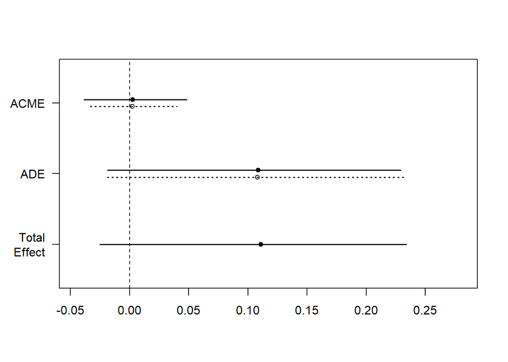

```r
plot(res)
```

- for development model

```r
##causal mediation analysis
###--> only supports 1 level - one random intercept

df_trial$baseline_pd_z<-scale(df_trial$baseline_pd)
df_medanalysis<-df_trial[df_trial$t %in% c('T2','FU2') & df_trial$rndm!='non autistic' & !is.na(df_trial$baseline_pd_z),]

glm_outcome<-glmer(rja_any~t*rndm+baseline_pd_z+
            (1|pic),
            data=df_medanalysis,family='binomial')

lmm_mod<-lme4::lmer(baseline_pd_z~t*rndm+
            (1|pic),data=df_medanalysis)

anova(glm_outcome)
```

```
## Analysis of Variance Table
##               npar  Sum Sq Mean Sq F value
## t                1 12.6971 12.6971 12.6971
## rndm             1  4.6367  4.6367  4.6367
## baseline_pd_z    1 26.7517 26.7517 26.7517
## t:rndm           1  0.3039  0.3039  0.3039
```

```r
anova(lmm_mod)
```

```
## Analysis of Variance Table
##        npar Sum Sq Mean Sq F value
## t         1 1.4672  1.4672  3.1390
## rndm      1 1.2745  1.2745  2.7266
## t:rndm    1 5.2972  5.2972 11.3329
```

```r
  glm_test<-glmer(rja_any~t*rndm+
            (1|pic),
            data=df_medanalysis,family='binomial')
  emmeans(glm_test,~rndm|t)
```

```
## t = T2:
##  rndm            emmean       SE  df asymp.LCL asymp.UCL
##  autistic A-FFIP -1.425 0.001412 Inf   -1.4281   -1.4226
##  autistic TAU    -2.050 0.001997 Inf   -2.0543   -2.0464
##
## t = FU2:
##  rndm            emmean       SE  df asymp.LCL asymp.UCL
##  autistic A-FFIP -0.425 0.001411 Inf   -0.4278   -0.4223
##  autistic TAU    -1.568 0.001996 Inf   -1.5717   -1.5639
##
## Results are given on the logit (not the response) scale.
## Confidence level used: 0.95
```

```r
res<-mediation::mediate(lmm_mod,glm_outcome,
                        treat = 'rndm',
                        mediator='baseline_pd_z',
                        treat.value = 'autistic A-FFIP',
                        control.value = 'autistic TAU',
                        covariates = list(t = 'FU2'), #check at FU2
                        sims=1000)

#save(res,file=paste0(project_path,'/data/casual_mediation_baselinePD.Rdata'))
#load(paste0(project_path,'/data/casual_mediation_baselinePD.Rdata'))
###--> saved and loaded as simulation can lead to different results between iterations

summary(res)
```

```
##
## Causal Mediation Analysis
##
## Quasi-Bayesian Confidence Intervals
##
## (Inference Conditional on the Covariate Values Specified in `covariates')
##
## Mediator Groups: pic
##
## Outcome Groups: pic
##
## Output Based on Overall Averages Across Groups
##
##                          Estimate 95% CI Lower 95% CI Upper p-value
## ACME (control)             0.0805       0.0259         0.15  <2e-16 ***
## ACME (treated)             0.0903       0.0332         0.16  <2e-16 ***
## ADE (control)              0.1413      -0.0432         0.34   0.174
## ADE (treated)              0.1511      -0.0462         0.36   0.174
## Total Effect               0.2316       0.0382         0.42   0.016 *
## Prop. Mediated (control)   0.3378       0.0907         1.73   0.016 *
## Prop. Mediated (treated)   0.3871       0.1187         1.69   0.016 *
## ACME (average)             0.0854       0.0295         0.15  <2e-16 ***
## ADE (average)              0.1462      -0.0447         0.34   0.174
## Prop. Mediated (average)   0.3624       0.1065         1.71   0.016 *
## ---
## Signif. codes:  0 '***' 0.001 '**' 0.01 '*' 0.05 '.' 0.1 ' ' 1
##
## Sample Size Used: 876
##
##
## Simulations: 1000
```

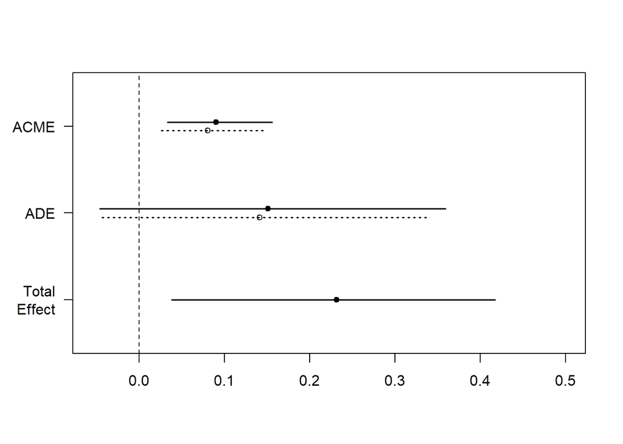

```r
plot(res)
```